# Exploratory: Post Engagement

- Show All Code
- Hide All Code
- View Source

How did participants react to the posts?

```r
load(here(data_dir, "analysis", "df_wide.RData"))
df <- df_wide
rm(df_wide)
```

### Manipulation Checks

```r
manip_balance_table <- df |>
  select(Treatment = exp_condition,
         "Anxiety-Hope" = anxiety_hope_dim,
         "Anxiety Rating" = exp_check_anxious,
         "Angry Rating" = exp_check_angry,
         "Hopeful Rating" = exp_check_hopeful,
         "Happy Rating" = exp_check_happy,
         "Calm Rating" = exp_check_calm,
         "Comment Sentiment" = exp_comment_sentiment) |>
  mutate(Treatment = factor(Treatment, levels = c("anxiety", "hope", "control"),
                            labels = c("Anxiety", "Hope", "Control"))) |>
  datasummary_balance(~Treatment,
                      data = _,
                      fmt = 2)

manip_balance_table |>
  save_tt(here(table_dir, "manipulation_balance.docx"), overwrite = TRUE)

manip_balance_table
```

|  | Anxiety (N=633) Mean | Anxiety (N=633) Std. Dev. | Hope (N=631) Mean | Hope (N=631) Std. Dev. | Control (N=631) Mean | Control (N=631) Std. Dev. |
| --- | --- | --- | --- | --- | --- | --- |
| Anxiety-Hope | 0.60 | 0.22 | 0.43 | 0.20 | 0.46 | 0.22 |
| Anxiety Rating | 61.11 | 26.91 | 42.86 | 27.91 | 47.16 | 27.41 |
| Angry Rating | 55.97 | 28.84 | 37.82 | 29.26 | 40.10 | 29.37 |
| Hopeful Rating | 41.82 | 29.80 | 57.38 | 28.56 | 56.16 | 27.25 |
| Happy Rating | 36.08 | 29.67 | 53.09 | 28.40 | 51.57 | 28.42 |
| Calm Rating | 38.29 | 28.96 | 53.56 | 27.70 | 50.46 | 27.82 |
| Comment Sentiment | 2.93 | 1.61 | 4.17 | 1.88 | 4.29 | 1.79 |

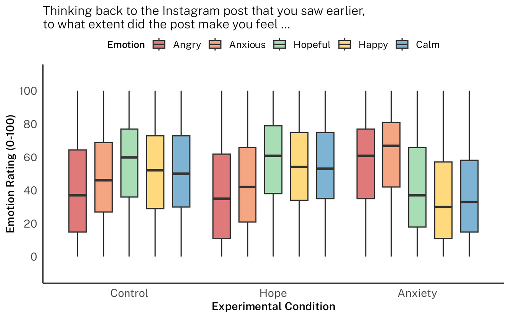

```r
manip_check_data <- df |>
  select(id, exp_condition, starts_with("exp_check")) |>
  pivot_longer(
    cols = starts_with("exp_check"),
    names_to = "emotion",
    values_to = "rating",
    names_prefix = "exp_check_"
  ) |>
  mutate(
    emotion = factor(emotion,
                     levels = c("angry", "anxious", "hopeful", "happy", "calm"),
                     labels = c("Angry", "Anxious", "Hopeful", "Happy", "Calm"))
  )

# Define emotion colors for the manipulation check boxplot
manip_check_colors <- c(
  "Angry" = "#e07a7a",
  "Anxious" = "#f4a582",
  "Hopeful" = "#a8ddb5",
  "Happy" = "#ffd97d",
  "Calm" = "#7eb3d4"
)

manip_check_data |>
  ggplot(aes(x = exp_condition, y = rating, fill = emotion)) +
  geom_boxplot(
    position = position_dodge(width = 0.9),
    width = 0.6,
    outlier.size = 0.8,
    outlier.alpha = 0.3
  ) +
  scale_fill_manual(
    values = manip_check_colors,
    name = "Emotion"
  ) +
  scale_x_discrete(
    labels = c("anxiety" = "Anxiety", "hope" = "Hope", "control" = "Control")
  ) +
  scale_y_continuous(
    limits = c(-10, 110),
    breaks = seq(0, 100, 20),
    expand = c(0.05, 0.05)
  ) +
  labs(
    x = "Experimental Condition",
    y = "Emotion Rating (0-100)",
    subtitle = "Thinking back to the Instagram post that you saw earlier,
to what extent did the post make you feel …"
  ) +
  theme_allround() +
  guides(fill = guide_legend(override.aes = list(shape = NA)))
```

```r
ggsave(here(figure_dir, "manipulation_check.svg"), width = 8, height = 5, web_fonts = svg_fonts)
```

```r
manip_pairwise <- manip_check_data |>
  group_by(emotion) |>
  pairwise_t_test(
    rating ~ exp_condition,
    detailed = TRUE,
    pool.sd = FALSE,
    p.adjust.method = "holm",
    ref.group = "control"
  ) |>
  ungroup()

manip_pairwise_table <- manip_pairwise |>
  select(Emotion = emotion,
         `Group 1` = group1,
         `Group 2` = group2,
         `Mean 1` = estimate1,
         `Mean 2` = estimate2,
         `Estimate` = estimate,
         p, p.adj,
         df) |>
  mutate(across(where(is.numeric), \(x) round(x, 3))) |>
  tt()

manip_pairwise_table
```

| Emotion | Group 1 | Group 2 | Mean 1 | Mean 2 | Estimate | p | p.adj | df |
| --- | --- | --- | --- | --- | --- | --- | --- | --- |
| Angry | control | hope | 40.09 | 37.82 | 2.273 | 0.169 | 0.169 | 1260 |
| Angry | control | anxiety | 40.09 | 55.97 | -15.873 | 0.000 | 0.000 | 1261 |
| Anxious | control | hope | 47.16 | 42.86 | 4.300 | 0.006 | 0.006 | 1260 |
| Anxious | control | anxiety | 47.16 | 61.11 | -13.955 | 0.000 | 0.000 | 1261 |
| Hopeful | control | hope | 56.16 | 57.38 | -1.225 | 0.436 | 0.436 | 1257 |
| Hopeful | control | anxiety | 56.16 | 41.81 | 14.340 | 0.000 | 0.000 | 1253 |
| Happy | control | hope | 51.57 | 53.09 | -1.525 | 0.341 | 0.341 | 1260 |
| Happy | control | anxiety | 51.57 | 36.08 | 15.490 | 0.000 | 0.000 | 1260 |
| Calm | control | hope | 50.46 | 53.56 | -3.098 | 0.048 | 0.048 | 1260 |
| Calm | control | anxiety | 50.46 | 38.29 | 12.170 | 0.000 | 0.000 | 1260 |

```r
manip_pairwise_table |>
  save_tt(here(table_dir, "manipulation_pairwise.docx"), overwrite = TRUE)
```

```r
# Helper function to create correlogram
scatter_function_grouped <- function(data, mapping, ...) {
  ggplot(data = data, mapping = mapping) +
    geom_point(alpha = 0.2, size = 1) +
    geom_smooth(method = "lm",
                se = TRUE,
                linewidth = 1.2,
                alpha = 0.5,
                na.rm = TRUE)
}
```

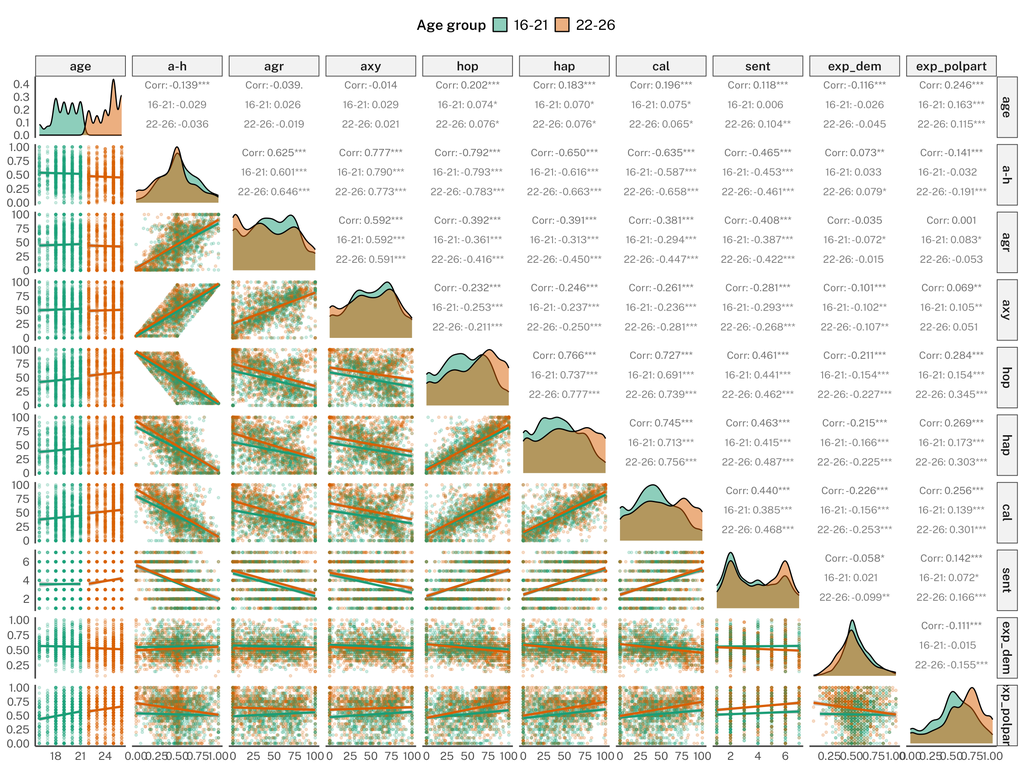

```r
manip_correlogram <- df |>
  mutate(age_group = as.character(age_group)) |>
  mutate(age_group = case_match(age_group,
    "16-21 years" ~ "16-21",
    "22-26 years" ~ "22-26"
  )) |>
  select(
    age_group,
    age,
    "a-h" = anxiety_hope_dim,
    agr = exp_check_angry,
    axy = exp_check_anxious,
    hop = exp_check_hopeful,
    hap = exp_check_happy,
    cal = exp_check_calm,
    sent = exp_comment_sentiment,
    exp_dem = exp_dem_pomp,
    exp_polpart = exp_polpart_pomp
  ) |>
  ggpairs(
    data = _,
    columns = 2:11,
    mapping = aes(color = age_group),
    lower = list(continuous = scatter_function_grouped),
    upper = list(continuous = wrap("cor", stars = TRUE, size = 4)),
    diag = list(continuous = wrap("densityDiag", alpha = 0.5)),
    legend = 1,
    progress = FALSE
  ) +
  scale_color_manual(values = c("16-21" = "#1b9e77",
                                "22-26" = "#d95f02")) +
  scale_fill_manual(values = c("16-21" = "#1b9e77",
                                "22-26" = "#d95f02")) +
  theme_allround() +
  theme(legend.text = element_text(size = 16),
        legend.title = element_text(size = 16)) +
  labs(color = "Age group", fill = "Age group")

manip_correlogram
```

```r
ggsave(here(figure_dir, "manip_correlogram.svg"), plot = manip_correlogram, width = 16, height = 12, web_fonts = svg_fonts)
```

### Comments, Liking, Sharing

```r
df |>
  select(Treatment = exp_condition,
         exp_comment_emotion,
         exp_reaction,
         exp_like,
         exp_share) |>
  mutate(Treatment = factor(Treatment, levels = c("anxiety", "hope", "control"),
                            labels = c("Anxiety", "Hope", "Control"))) |>
  datasummary_balance(~Treatment,
                      data = _)
```

|  |  | Anxiety (N=633) N | Anxiety (N=633) Pct. | Hope (N=631) N | Hope (N=631) Pct. | Control (N=631) N | Control (N=631) Pct. |
| --- | --- | --- | --- | --- | --- | --- | --- |
| exp_comment_emotion | angry | 119 | 18.8 | 85 | 13.5 | 86 | 13.6 |
|  | anxious | 271 | 42.8 | 134 | 21.2 | 137 | 21.7 |
|  | hopeful | 66 | 10.4 | 222 | 35.2 | 109 | 17.3 |
|  | happy | 26 | 4.1 | 49 | 7.8 | 94 | 14.9 |
|  | calm | 52 | 8.2 | 44 | 7.0 | 97 | 15.4 |
| exp_reaction | Angry | 118 | 18.6 | 74 | 11.7 | 67 | 10.6 |
|  | Anxious | 372 | 58.8 | 156 | 24.7 | 186 | 29.5 |
|  | Calm | 76 | 12.0 | 214 | 33.9 | 203 | 32.2 |
|  | Hopeful | 43 | 6.8 | 139 | 22.0 | 131 | 20.8 |
|  | Happy | 24 | 3.8 | 48 | 7.6 | 44 | 7.0 |
| exp_like | Very unlikely | 76 | 12.0 | 104 | 16.5 | 85 | 13.5 |
|  | Unlikely | 99 | 15.6 | 101 | 16.0 | 111 | 17.6 |
|  | Neither likely nor unlikely | 130 | 20.5 | 124 | 19.7 | 128 | 20.3 |
|  | Likely | 218 | 34.4 | 199 | 31.5 | 215 | 34.1 |
|  | Very likely | 110 | 17.4 | 103 | 16.3 | 92 | 14.6 |
| exp_share | Very unlikely | 87 | 13.7 | 111 | 17.6 | 107 | 17.0 |
|  | Unlikely | 130 | 20.5 | 136 | 21.6 | 151 | 23.9 |
|  | Neither likely nor unlikely | 157 | 24.8 | 145 | 23.0 | 160 | 25.4 |
|  | Likely | 182 | 28.8 | 167 | 26.5 | 157 | 24.9 |
|  | Very likely | 77 | 12.2 | 72 | 11.4 | 56 | 8.9 |

#### Sharing of Post

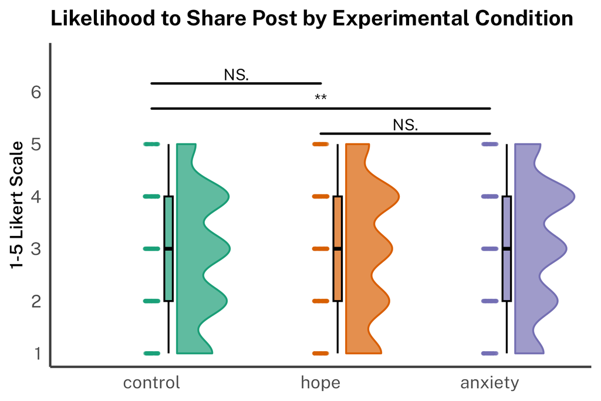

```r
df |>
  mutate(exp_share = as.numeric(exp_share)) |>
  ggplot(aes(x = exp_condition, y = exp_share, fill = exp_condition, color = exp_condition)) +
  geom_rain(
    rain.side = "r",
    seed = 42,
    point.args = list(alpha = 0.2, size = 0.8),
    boxplot.args = list(
      outlier.shape = NA,
      alpha = 0.7,
      color = "black"
    ),
    violin.args = list(alpha = 0.7)
  ) +
  geom_signif(
    aes(x = exp_condition, y = exp_share),
    comparisons = list(
      c("anxiety", "hope"),
      c("anxiety", "control"),
      c("hope", "control")
    ),
    map_signif_level = TRUE,
    size = 0.8,
    textsize = 4,
    family = "Public Sans Regular",
    color = "black",
    tip_length = 0,
    step_increase = 0.12,
    inherit.aes = FALSE
  ) +
  scale_fill_brewer(palette = "Dark2") +
  scale_color_brewer(palette = "Dark2") +
  scale_y_continuous(expand = expansion(mult = c(0.05, 0.15))) +
  labs(
    x = NULL,
    y = "1-5 Likert Scale",
    title = "Likelihood to Share Post by Experimental Condition"
  ) +
  theme_allround() +
  theme(legend.position = "none")
```

```r
ggsave(here(figure_dir, "share_raincloud.svg"), width = 6, height = 4, web_fonts = svg_fonts)
```

```r
share_pairwise <- df |>
  mutate(exp_share = as.numeric(exp_share)) |>
  pairwise_t_test(
    exp_share ~ exp_condition,
    detailed = TRUE,
    pool.sd = FALSE,
    p.adjust.method = "holm"
  )

share_pairwise_table <- share_pairwise |>
  select(`Group 1` = group1,
         `Group 2` = group2,
         `Mean 1` = estimate1,
         `Mean 2` = estimate2,
         `Estimate` = estimate,
         p, p.adj,
         df) |>
  mutate(across(where(is.numeric), \(x) round(x, 3))) |>
  tt()

share_pairwise_table
```

| Group 1 | Group 2 | Mean 1 | Mean 2 | Estimate | p | p.adj | df |
| --- | --- | --- | --- | --- | --- | --- | --- |
| control | hope | 2.848 | 2.926 | -0.078 | 0.271 | 0.271 | 1258 |
| control | anxiety | 2.848 | 3.051 | -0.203 | 0.003 | 0.010 | 1262 |
| hope | anxiety | 2.926 | 3.051 | -0.125 | 0.078 | 0.155 | 1260 |

```r
share_pairwise_table |>
  save_tt(here(table_dir, "share_pairwise.docx"), overwrite = TRUE)
```

#### Liking of Post

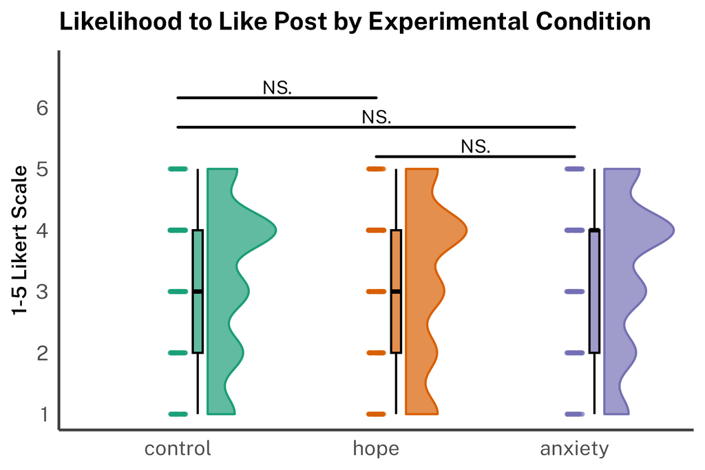

```r
df |>
  mutate(exp_like = as.numeric(exp_like)) |>
  ggplot(aes(x = exp_condition, y = exp_like, fill = exp_condition, color = exp_condition)) +
  geom_rain(
    rain.side = "r",
    seed = 42,
    point.args = list(alpha = 0.2, size = 0.8),
    boxplot.args = list(
      outlier.shape = NA,
      alpha = 0.7,
      color = "black"
    ),
    violin.args = list(alpha = 0.7)
  ) +
  geom_signif(
    aes(x = exp_condition, y = exp_like),
    comparisons = list(
      c("anxiety", "hope"),
      c("anxiety", "control"),
      c("hope", "control")
    ),
    map_signif_level = TRUE,
    size = 0.8,
    textsize = 4,
    family = "Public Sans Regular",
    color = "black",
    tip_length = 0,
    step_increase = 0.12,
    inherit.aes = FALSE
  ) +
  scale_fill_brewer(palette = "Dark2") +
  scale_color_brewer(palette = "Dark2") +
  scale_y_continuous(expand = expansion(mult = c(0.05, 0.15))) +
  labs(
    x = NULL,
    y = "1-5 Likert Scale",
    title = "Likelihood to Like Post by Experimental Condition"
  ) +
  theme_allround() +
  theme(legend.position = "none")
```

```r
ggsave(here(figure_dir, "like_raincloud.svg"), width = 6, height = 4, web_fonts = svg_fonts)
```

```r
like_pairwise <- df |>
  mutate(exp_like = as.numeric(exp_like)) |>
  pairwise_t_test(
    exp_like ~ exp_condition,
    detailed = TRUE,
    pool.sd = FALSE,
    p.adjust.method = "holm"
  )

like_pairwise_table <- like_pairwise |>
  select(`Group 1` = group1,
         `Group 2` = group2,
         `Mean 1` = estimate1,
         `Mean 2` = estimate2,
         `Estimate` = estimate,
         p, p.adj,
         df) |>
  mutate(across(where(is.numeric), \(x) round(x, 3))) |>
  tt()

like_pairwise_table
```

| Group 1 | Group 2 | Mean 1 | Mean 2 | Estimate | p | p.adj | df |
| --- | --- | --- | --- | --- | --- | --- | --- |
| control | hope | 3.187 | 3.152 | 0.035 | 0.634 | 0.634 | 1257 |
| control | anxiety | 3.187 | 3.295 | -0.108 | 0.128 | 0.256 | 1262 |
| hope | anxiety | 3.152 | 3.295 | -0.143 | 0.050 | 0.149 | 1258 |

```r
like_pairwise_table |>
  save_tt(here(table_dir, "like_pairwise.docx"), overwrite = TRUE)
```

### Exploratory Manipulation Check Models

```r
# brms settings
bayes_seed <- 42
chains <- 4
iter <- 4000
warmup <- floor(iter/2)
adapt_delta <- 0.90
max_treedepth <- 10

# marginaleffects settings
options(marginaleffects_posterior_interval = "hdi")
options(marginaleffects_posterior_center = stats::median)
```

```r
df_mod <- df |>
  mutate(across(c(exp_share, exp_like), as.numeric)) |>
  mutate(exp_share_pomp = (exp_share - 1) / 4,
         exp_like_pomp = (exp_like - 1) / 4,
         comment_sentiment_pomp = (exp_comment_sentiment - 1) / 6,
         Anxious = exp_check_anxious / 100,
         Angry = exp_check_angry / 100,
         Hopeful = exp_check_hopeful / 100,
         Happy = exp_check_happy / 100,
         Calm = exp_check_calm / 100)
```

```r
priors <- c(
  prior(normal(0.5, 0.5), class = "Intercept"),
  prior(normal(0, 0.5), class = "b"),
  prior(exponential(4), class = "sigma"))
```

#### Anxiety-Hope Dimension

```r
ah1 <- brm(
  data = df_mod,
  family = gaussian(),
  formula = anxiety_hope_dim ~ exp_condition,
  prior = priors,
  sample_prior = "yes",
  init = "random",
  chains = chains,
  iter = iter,
  warmup = warmup,
  seed = bayes_seed,
  control = list(
    adapt_delta = adapt_delta,
    max_treedepth = max_treedepth),
  file = here(model_dir, "ah1.rds")
  )
```

```r
print(ah1)
```

```
 Family: gaussian
  Links: mu = identity
Formula: anxiety_hope_dim ~ exp_condition
   Data: df_mod (Number of observations: 1895)
  Draws: 4 chains, each with iter = 4000; warmup = 2000; thin = 1;
         total post-warmup draws = 8000

Regression Coefficients:
                     Estimate Est.Error l-95% CI u-95% CI Rhat Bulk_ESS Tail_ESS
Intercept                0.46      0.01     0.44     0.47 1.00     6972     5785
exp_conditionhope       -0.03      0.01    -0.05    -0.00 1.00     7407     5472
exp_conditionanxiety     0.14      0.01     0.12     0.17 1.00     7173     5729

Further Distributional Parameters:
      Estimate Est.Error l-95% CI u-95% CI Rhat Bulk_ESS Tail_ESS
sigma     0.21      0.00     0.21     0.22 1.00     7511     5596

Draws were sampled using sample(hmc). For each parameter, Bulk_ESS
and Tail_ESS are effective sample size measures, and Rhat is the potential
scale reduction factor on split chains (at convergence, Rhat = 1).
```

#### Sentiment

```r
sent1 <- brm(
  data = df_mod,
  family = gaussian(),
  formula = comment_sentiment_pomp ~ exp_condition,
  prior = priors,
  sample_prior = "yes",
  init = "random",
  chains = chains,
  iter = iter,
  warmup = warmup,
  seed = bayes_seed,
  control = list(
    adapt_delta = adapt_delta,
    max_treedepth = max_treedepth)
  )
```

```r
print(sent1)
```

```
 Family: gaussian
  Links: mu = identity
Formula: comment_sentiment_pomp ~ exp_condition
   Data: df_mod (Number of observations: 1556)
  Draws: 4 chains, each with iter = 4000; warmup = 2000; thin = 1;
         total post-warmup draws = 8000

Regression Coefficients:
                     Estimate Est.Error l-95% CI u-95% CI Rhat Bulk_ESS Tail_ESS
Intercept                0.55      0.01     0.52     0.57 1.00     6799     6023
exp_conditionhope       -0.02      0.02    -0.06     0.01 1.00     6954     5993
exp_conditionanxiety    -0.23      0.02    -0.26    -0.19 1.00     6728     5872

Further Distributional Parameters:
      Estimate Est.Error l-95% CI u-95% CI Rhat Bulk_ESS Tail_ESS
sigma     0.29      0.01     0.28     0.30 1.00     8738     5842

Draws were sampled using sample(hmc). For each parameter, Bulk_ESS
and Tail_ESS are effective sample size measures, and Rhat is the potential
scale reduction factor on split chains (at convergence, Rhat = 1).
```

#### Sharing of Post

```r
share1 <- brm(
  data = df_mod,
  family = gaussian(),
  formula = exp_share_pomp ~ exp_condition,
  prior = priors,
  sample_prior = "yes",
  init = "random",
  chains = chains,
  iter = iter,
  warmup = warmup,
  seed = bayes_seed,
  control = list(
    adapt_delta = adapt_delta,
    max_treedepth = max_treedepth)
  )
```

```r
print(share1)
```

```
 Family: gaussian
  Links: mu = identity
Formula: exp_share_pomp ~ exp_condition
   Data: df_mod (Number of observations: 1895)
  Draws: 4 chains, each with iter = 4000; warmup = 2000; thin = 1;
         total post-warmup draws = 8000

Regression Coefficients:
                     Estimate Est.Error l-95% CI u-95% CI Rhat Bulk_ESS Tail_ESS
Intercept                0.46      0.01     0.44     0.49 1.00     7480     5775
exp_conditionhope        0.02      0.02    -0.01     0.05 1.00     7423     6061
exp_conditionanxiety     0.05      0.02     0.02     0.09 1.00     7578     6422

Further Distributional Parameters:
      Estimate Est.Error l-95% CI u-95% CI Rhat Bulk_ESS Tail_ESS
sigma     0.31      0.01     0.30     0.32 1.00     8038     5843

Draws were sampled using sample(hmc). For each parameter, Bulk_ESS
and Tail_ESS are effective sample size measures, and Rhat is the potential
scale reduction factor on split chains (at convergence, Rhat = 1).
```

#### Liking of Post

```r
like1 <- brm(
  data = df_mod,
  family = gaussian(),
  formula = exp_like_pomp ~ exp_condition,
  prior = priors,
  sample_prior = "yes",
  init = "random",
  chains = chains,
  iter = iter,
  warmup = warmup,
  seed = bayes_seed,
  control = list(
    adapt_delta = adapt_delta,
    max_treedepth = max_treedepth)
  )
```

```r
print(like1)
```

```
 Family: gaussian
  Links: mu = identity
Formula: exp_like_pomp ~ exp_condition
   Data: df_mod (Number of observations: 1895)
  Draws: 4 chains, each with iter = 4000; warmup = 2000; thin = 1;
         total post-warmup draws = 8000

Regression Coefficients:
                     Estimate Est.Error l-95% CI u-95% CI Rhat Bulk_ESS Tail_ESS
Intercept                0.55      0.01     0.52     0.57 1.00     7284     5524
exp_conditionhope       -0.01      0.02    -0.04     0.03 1.00     7112     6482
exp_conditionanxiety     0.03      0.02    -0.01     0.06 1.00     7395     5799

Further Distributional Parameters:
      Estimate Est.Error l-95% CI u-95% CI Rhat Bulk_ESS Tail_ESS
sigma     0.32      0.01     0.31     0.33 1.00     8417     5939

Draws were sampled using sample(hmc). For each parameter, Bulk_ESS
and Tail_ESS are effective sample size measures, and Rhat is the potential
scale reduction factor on split chains (at convergence, Rhat = 1).
```

#### Emotion Ratings

```r
# Create formula with set_rescor
f_er1 <- bf(mvbind(Anxious, Angry, Hopeful, Happy, Calm) ~ exp_condition) +
  set_rescor(FALSE)

# Specify priors for each response variable
priors_er <- c(
  prior(normal(0.5, 0.5), class = "Intercept", resp = "Anxious"),
  prior(normal(0.5, 0.5), class = "Intercept", resp = "Angry"),
  prior(normal(0.5, 0.5), class = "Intercept", resp = "Hopeful"),
  prior(normal(0.5, 0.5), class = "Intercept", resp = "Happy"),
  prior(normal(0.5, 0.5), class = "Intercept", resp = "Calm"),
  prior(normal(0, 0.5), class = "b", resp = "Anxious"),
  prior(normal(0, 0.5), class = "b", resp = "Angry"),
  prior(normal(0, 0.5), class = "b", resp = "Hopeful"),
  prior(normal(0, 0.5), class = "b", resp = "Happy"),
  prior(normal(0, 0.5), class = "b", resp = "Calm"),
  prior(exponential(4), class = "sigma", resp = "Anxious"),
  prior(exponential(4), class = "sigma", resp = "Angry"),
  prior(exponential(4), class = "sigma", resp = "Hopeful"),
  prior(exponential(4), class = "sigma", resp = "Happy"),
  prior(exponential(4), class = "sigma", resp = "Calm")
)
```

```r
er1 <- brm(
  data = df_mod,
  family = gaussian(),
  formula = f_er1,
  prior = priors_er,
  sample_prior = "yes",
  init = "random",
  chains = chains,
  iter = iter,
  warmup = warmup,
  seed = bayes_seed,
  control = list(
    adapt_delta = adapt_delta,
    max_treedepth = max_treedepth
  )
)
```

```r
print(er1)
```

```
 Family: MV(gaussian, gaussian, gaussian, gaussian, gaussian)
  Links: mu = identity
         mu = identity
         mu = identity
         mu = identity
         mu = identity
Formula: Anxious ~ exp_condition
         Angry ~ exp_condition
         Hopeful ~ exp_condition
         Happy ~ exp_condition
         Calm ~ exp_condition
   Data: df_mod (Number of observations: 1895)
  Draws: 4 chains, each with iter = 4000; warmup = 2000; thin = 1;
         total post-warmup draws = 8000

Regression Coefficients:
                             Estimate Est.Error l-95% CI u-95% CI Rhat Bulk_ESS Tail_ESS
Anxious_Intercept                0.47      0.01     0.45     0.49 1.00     8061     6198
Angry_Intercept                  0.40      0.01     0.38     0.42 1.00     7713     6089
Hopeful_Intercept                0.56      0.01     0.54     0.58 1.00     8157     5873
Happy_Intercept                  0.52      0.01     0.49     0.54 1.00     7307     6051
Calm_Intercept                   0.50      0.01     0.48     0.53 1.00     6846     5933
Anxious_exp_conditionhope       -0.04      0.02    -0.07    -0.01 1.00     8058     6127
Anxious_exp_conditionanxiety     0.14      0.02     0.11     0.17 1.00     8270     6721
Angry_exp_conditionhope         -0.02      0.02    -0.05     0.01 1.00     7555     6152
Angry_exp_conditionanxiety       0.16      0.02     0.13     0.19 1.00     7675     6423
Hopeful_exp_conditionhope        0.01      0.02    -0.02     0.04 1.00     8385     6643
Hopeful_exp_conditionanxiety    -0.14      0.02    -0.18    -0.11 1.00     8105     6250
Happy_exp_conditionhope          0.02      0.02    -0.02     0.05 1.00     7608     6500
Happy_exp_conditionanxiety      -0.15      0.02    -0.19    -0.12 1.00     7724     6460
Calm_exp_conditionhope           0.03      0.02    -0.00     0.06 1.00     7489     6103
Calm_exp_conditionanxiety       -0.12      0.02    -0.15    -0.09 1.00     7138     5893

Further Distributional Parameters:
              Estimate Est.Error l-95% CI u-95% CI Rhat Bulk_ESS Tail_ESS
sigma_Anxious     0.27      0.00     0.27     0.28 1.00     9436     5843
sigma_Angry       0.29      0.00     0.28     0.30 1.00    10069     5908
sigma_Hopeful     0.29      0.00     0.28     0.30 1.00    10148     6245
sigma_Happy       0.29      0.00     0.28     0.30 1.00     9739     6102
sigma_Calm        0.28      0.00     0.27     0.29 1.00     9774     5445

Draws were sampled using sample(hmc). For each parameter, Bulk_ESS
and Tail_ESS are effective sample size measures, and Rhat is the potential
scale reduction factor on split chains (at convergence, Rhat = 1).
```

### Visualise

#### Part 1

```r
# Prepare predictions for all models
models_list <- list(
  ah1 = ah1,
  sent1 = sent1,
  share1 = share1,
  like1 = like1
)

outcome_labels <- c(
  ah1 = "Anxiety-Hope Dimension",
  sent1 = "Comment Sentiment",
  share1 = "Likelihood to Share",
  like1 = "Likelihood to Like"
)

predictions <- map_dfr(names(models_list), function(model_name) {
  expand_grid(
    exp_condition = c("control", "anxiety", "hope")
  ) |>
    add_epred_draws(models_list[[model_name]], re_formula = NA) |>
    ungroup() |>
    mutate(
      outcome = model_name,
      outcome_label = outcome_labels[model_name],
      .epred = .epred * 100  # Convert to percentage points
    )
})

# Calculate pairwise contrasts and check if they exclude zero
contrasts <- predictions |>
  select(outcome, outcome_label, exp_condition, .draw, .epred) |>
  pivot_wider(names_from = exp_condition, values_from = .epred) |>
  mutate(
    anxiety_vs_control = anxiety - control,
    hope_vs_control = hope - control,
    anxiety_vs_hope = anxiety - hope
  )

contrast_summary <- contrasts |>
  group_by(outcome, outcome_label) |>
  summarise(
    across(
      c(anxiety_vs_control, hope_vs_control, anxiety_vs_hope),
      list(
        lower = ~hdi(.x, .width = 0.95)[[1]],
        upper = ~hdi(.x, .width = 0.95)[[2]]
      ),
      .names = "{.col}_{.fn}"
    ),
    .groups = "drop"
  ) |>
  mutate(
    anxiety_diff_control = sign(anxiety_vs_control_lower) == sign(anxiety_vs_control_upper),
    hope_diff_control = sign(hope_vs_control_lower) == sign(hope_vs_control_upper),
    anxiety_diff_hope = sign(anxiety_vs_hope_lower) == sign(anxiety_vs_hope_upper)
  )

# Generate compact letter display
cld_labels <- contrast_summary |>
  mutate(
    control_label = case_when(
      # Intransitivity: control bridges anxiety and hope
      !anxiety_diff_control & !hope_diff_control & anxiety_diff_hope ~ "ab",
      TRUE ~ "a"
    ),
    anxiety_label = case_when(
      # Anxiety bridges control and hope
      !anxiety_diff_control & hope_diff_control & !anxiety_diff_hope ~ "ab",
      # Anxiety same as control
      !anxiety_diff_control & !anxiety_diff_hope              ~ "a",
      !anxiety_diff_control & anxiety_diff_hope               ~ "a",
      # Anxiety differs from control
      anxiety_diff_control  & !anxiety_diff_hope              ~ "b",
      anxiety_diff_control  & anxiety_diff_hope               ~ "b"
    ),
    hope_label = case_when(
      # Hope bridges control and anxiety
      !hope_diff_control & !anxiety_diff_hope & anxiety_diff_control  ~ "ab",
      # Intransitivity: hope=b (control bridges)
      !hope_diff_control & anxiety_diff_hope  & !anxiety_diff_control ~ "b",
      # All same
      !hope_diff_control & !anxiety_diff_hope & !anxiety_diff_control ~ "a",
      # Hope~control, anxiety differs from both
      !hope_diff_control & anxiety_diff_hope  & anxiety_diff_control  ~ "a",
      # Hope differs from control
      hope_diff_control  & !anxiety_diff_hope                         ~ "b",
      hope_diff_control  & anxiety_diff_hope  ~ if_else(anxiety_diff_control, "c", "b")
    )
  ) |>
  select(outcome, outcome_label, control_label, anxiety_label, hope_label) |>
  pivot_longer(
    cols = c(control_label, anxiety_label, hope_label),
    names_to = "condition",
    values_to = "cld"
  ) |>
  mutate(exp_condition = str_remove(condition, "_label")) |>
  select(outcome, outcome_label, exp_condition, cld)

# Combine plotting data with CLD labels
plot_data <- predictions |>
  left_join(cld_labels, by = c("outcome", "outcome_label", "exp_condition"))

# Check the CLD labels
cld_labels |>
  pivot_wider(names_from = exp_condition, values_from = cld) |>
  arrange(outcome)
```

```
# A tibble: 4 × 5
  outcome outcome_label          control anxiety hope
  <chr>   <chr>                  <chr>   <chr>   <chr>
1 ah1     Anxiety-Hope Dimension a       b       c
2 like1   Likelihood to Like     ab      a       b
3 sent1   Comment Sentiment      a       b       a
4 share1  Likelihood to Share    a       b       ab
```

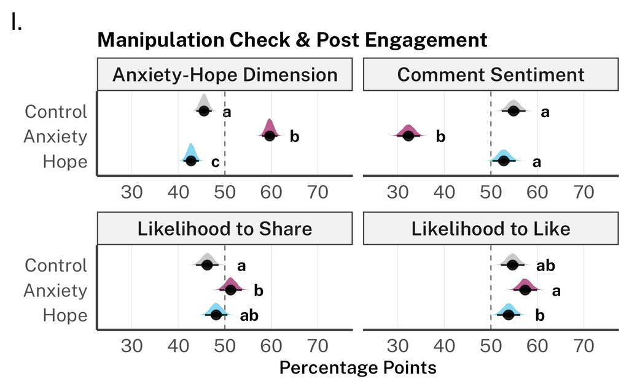

```r
part1 <- plot_data |>
  mutate(
    outcome_label = factor(
      outcome_label,
      levels = c("Anxiety-Hope Dimension", "Comment Sentiment",
                 "Likelihood to Share", "Likelihood to Like")
    ),
    exp_condition = factor(
      exp_condition,
      levels = c("hope", "anxiety", "control"),
      labels = c("Hope", "Anxiety", "Control")
    )
  ) |>
  ggplot(aes(x = .epred, y = exp_condition, fill = exp_condition)) +
  stat_halfeye(
    .width = c(0.95, 0.66),
    point_interval = "median_qi",
    alpha = 0.8,
    height = 0.8
  ) +
  geom_text(
    data = plot_data |>
      mutate(
        outcome_label = factor(
          outcome_label,
          levels = c("Anxiety-Hope Dimension", "Comment Sentiment",
                     "Likelihood to Share", "Likelihood to Like")
        ),
        exp_condition = factor(
          exp_condition,
          levels = c("hope", "anxiety", "control"),
          labels = c("Hope", "Anxiety", "Control")
        )
      ) |>
      group_by(outcome_label, exp_condition, cld) |>
      summarise(x_pos = max(.epred) + 2, .groups = "drop"),
    aes(x = x_pos, y = exp_condition, label = cld),
    size = 4,
    family = "Public Sans Bold",
    inherit.aes = FALSE
  ) +
  geom_vline(xintercept = 50, linetype = "dashed", color = "gray40", linewidth = 0.4) +
  facet_wrap(~outcome_label, scales = "free_x", ncol = 2, labeller = labeller(label_both)) +
  scale_fill_manual(
    values = c("Anxiety" = "#AA3377", "Hope" = "#66CCEE", "Control" = "#BBBBBB")
  ) +
  scale_x_continuous(breaks = seq(20, 80, by = 10)) +
  coord_cartesian(xlim = c(25, 75)) +
  labs(
    x = "Percentage Points",
    y = NULL,
    title = "Manipulation Check & Post Engagement",
    tag = "I."
  ) +
  theme_allround() +
  theme(
    legend.position = "none",
    panel.grid.major.x = element_line(color = "grey90", linewidth = 0.2),
    strip.text = element_text(size = rel(0.95)),
    plot.title = element_text(size = rel(1), margin = margin(b = 5))
  )

part1
```

```r
ggsave(here(figure_dir, "manip_engagement_fig.svg"), width = 6, height = 5, web_fonts = svg_fonts)
```

#### Part 2

```r
# Extract predictions for all emotions
emotion_predictions <- expand_grid(
  exp_condition = c("control", "anxiety", "hope")
) |>
  add_epred_draws(er1, re_formula = NA) |>
  ungroup() |>
  mutate(.epred = .epred * 100)

# Calculate pairwise contrasts
emotion_contrasts <- emotion_predictions |>
  select(.category, exp_condition, .draw, .epred) |>
  pivot_wider(names_from = exp_condition, values_from = .epred) |>
  mutate(
    anxiety_vs_control = anxiety - control,
    hope_vs_control = hope - control,
    anxiety_vs_hope = anxiety - hope
  )

emotion_contrast_summary <- emotion_contrasts |>
  group_by(.category) |>
  summarise(
    across(
      c(anxiety_vs_control, hope_vs_control, anxiety_vs_hope),
      list(
        lower = ~hdi(.x, .width = 0.95)[[1]],
        upper = ~hdi(.x, .width = 0.95)[[2]]
      ),
      .names = "{.col}_{.fn}"
    ),
    .groups = "drop"
  ) |>
  mutate(
    anxiety_diff_control = sign(anxiety_vs_control_lower) == sign(anxiety_vs_control_upper),
    hope_diff_control = sign(hope_vs_control_lower) == sign(hope_vs_control_upper),
    anxiety_diff_hope = sign(anxiety_vs_hope_lower) == sign(anxiety_vs_hope_upper)
  )

# Generate compact letter display
emotion_cld <- emotion_contrast_summary |>
  mutate(
    control_label = case_when(
      !anxiety_diff_control & !hope_diff_control & anxiety_diff_hope ~ "ab",
      TRUE ~ "a"
    ),
    anxiety_label = case_when(
      !anxiety_diff_control & hope_diff_control & !anxiety_diff_hope ~ "ab",
      !anxiety_diff_control & !anxiety_diff_hope                     ~ "a",
      !anxiety_diff_control & anxiety_diff_hope                      ~ "a",
      anxiety_diff_control  & !anxiety_diff_hope                     ~ "b",
      anxiety_diff_control  & anxiety_diff_hope                      ~ "b"
    ),
    hope_label = case_when(
      !hope_diff_control & !anxiety_diff_hope & anxiety_diff_control  ~ "ab",
      !hope_diff_control & anxiety_diff_hope  & !anxiety_diff_control ~ "b",
      !hope_diff_control & !anxiety_diff_hope & !anxiety_diff_control ~ "a",
      !hope_diff_control & anxiety_diff_hope  & anxiety_diff_control  ~ "a",
      hope_diff_control  & !anxiety_diff_hope                         ~ "b",
      hope_diff_control  & anxiety_diff_hope  ~ if_else(anxiety_diff_control, "c", "b")
    )
  ) |>
  select(.category, control_label, anxiety_label, hope_label) |>
  pivot_longer(
    cols = c(control_label, anxiety_label, hope_label),
    names_to = "condition",
    values_to = "cld"
  ) |>
  mutate(exp_condition = str_remove(condition, "_label")) |>
  select(.category, exp_condition, cld)

# Combine plotting data
emotion_plot_data <- emotion_predictions |>
  left_join(emotion_cld, by = c(".category", "exp_condition"))

# Emotion colors for parts 2 and 3
emotion_colors <- c(
  "Anxious" = "#AA3377",
  "Angry" = "#EE6677",
  "Calm" = "#CCBB44",
  "Hopeful" = "#66CCEE",
  "Happy" = "#4477AA"
)
```

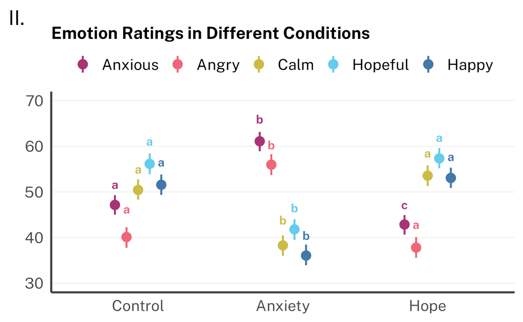

```r
part2 <- emotion_plot_data |>
  mutate(
    emotion = factor(
      .category,
      levels = c("Anxious", "Angry", "Calm", "Hopeful", "Happy"),
      labels = c("Anxious", "Angry", "Calm", "Hopeful", "Happy")
    ),
    exp_condition = factor(
      exp_condition,
      levels = c("control", "anxiety", "hope"),
      labels = c("Control", "Anxiety", "Hope")
    )
  ) |>
  ggplot(aes(x = exp_condition, y = .epred, color = emotion, group = emotion)) +
  stat_pointinterval(
    .width = 0.95,
    point_interval = "median_hdi",
    position = position_dodge(width = 0.4),
    point_size = 3,
    linewidth = 2
  ) +
  geom_text(
    data = emotion_plot_data |>
      mutate(
        emotion = factor(
          .category,
          levels = c("Anxious", "Angry", "Calm", "Hopeful", "Happy"),
          labels = c("Anxious", "Angry", "Calm", "Hopeful", "Happy")
        ),
        exp_condition = factor(
          exp_condition,
          levels = c("control", "anxiety", "hope"),
          labels = c("Control", "Anxiety", "Hope")
        )
      ) |>
      group_by(emotion, exp_condition, cld) |>
      summarise(y_pos = max(.epred) + 0.5, .groups = "drop"),
    aes(x = exp_condition, y = y_pos, label = cld, color = emotion),
    position = position_dodge(width = 0.4),
    size = 3.5,
    family = "Public Sans Bold",
    show.legend = FALSE
  ) +
  scale_y_continuous(limits = c(30, 70), breaks = seq(20, 80, by = 10)) +
  scale_color_manual(
    values = emotion_colors,
    name = NULL
  ) +
  labs(
    x = NULL,
    y = NULL,
    title = "Emotion Ratings in Different Conditions",
    tag = "II."
  ) +
  theme_allround() +
  theme(
    plot.title = element_text(size = rel(1)),
    panel.grid.major.y = element_line(color = "grey90", linewidth = 0.2),
    legend.text = element_text(size = rel(0.9))
  )

part2
```

```r
ggsave(here(figure_dir, "manip_emotions_fig.svg"), width = 6, height = 3.5, web_fonts = svg_fonts)
```

#### Part 3

```r
# Emoji shown to participants for each reaction
reaction_emoji <- c(
  "Angry"   = "\U0001F621", # rage
  "Anxious" = "\U0001F628", # fearful
  "Calm"    = "\U0001F60C", # relieved
  "Hopeful" = "\U0001F60A", # blush
  "Happy"   = "\U0001F601"  # grin
)

reaction_plot_data <- df_mod |>
  filter(!is.na(exp_reaction)) |>
  mutate(
    exp_condition = factor(
      exp_condition,
      levels = c("control", "anxiety", "hope"),
      labels = c("Control", "Anxiety", "Hope")
    ),
    exp_reaction = factor(
      exp_reaction,
      levels = c("Happy", "Hopeful", "Calm", "Angry", "Anxious")
    )
  ) |>
  count(exp_condition, exp_reaction) |>
  group_by(exp_condition) |>
  mutate(
    total = sum(n),
    pct = n / total * 100,
    emoji_label = if_else(pct >= 1, reaction_emoji[as.character(exp_reaction)], ""),
    pct_label = if_else(pct >= 1, sprintf("%.0f%%", pct), "")
  ) |>
  ungroup()
```

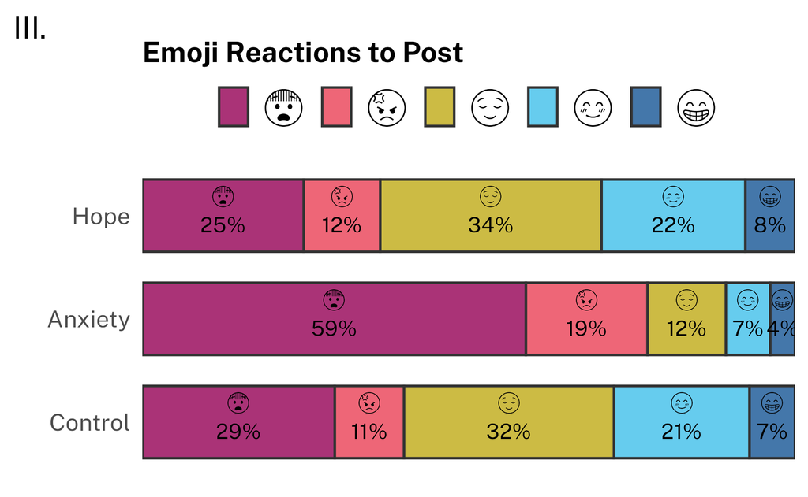

```r
part3 <- reaction_plot_data |>
  ggplot(aes(x = pct, y = exp_condition, fill = exp_reaction)) +
  geom_col(position = "stack", width = 0.7, color = "grey20") +
  # Emoji just above the middle of each segment, percentage just below
  geom_text(
    aes(label = emoji_label),
    position = position_stack(vjust = 0.5),
    vjust = -0.6,
    size = 4,
    family = "Noto Emoji"
  ) +
  geom_text(
    aes(label = pct_label),
    position = position_stack(vjust = 0.5),
    vjust = 1.1,
    size = 4
  ) +
  scale_fill_manual(
    values = emotion_colors,
    labels = reaction_emoji,
    name = NULL
  ) +
  scale_x_continuous(
    labels = scales::percent_format(scale = 1),
    expand = c(0, 0)
  ) +
  labs(
    x = NULL,
    y = NULL,
    title = "Emoji Reactions to Post",
    tag = "III."
  ) +
  theme_allround() +
  theme(
    axis.line.x = element_blank(),
    axis.line.y = element_blank(),
    axis.text.x = element_blank(),
    # bottom margin lifts the emoji to line up with the legend keys
    legend.text = element_text(family = "Noto Emoji", size = 20, margin = margin(l = 5.5, b = 4))
  ) +
  guides(fill = guide_legend(reverse = TRUE))

part3
```

```r
ggsave(here(figure_dir, "reaction_emotions_fig.svg"), width = 6.5, height = 4, web_fonts = svg_fonts)
```

#### Grid

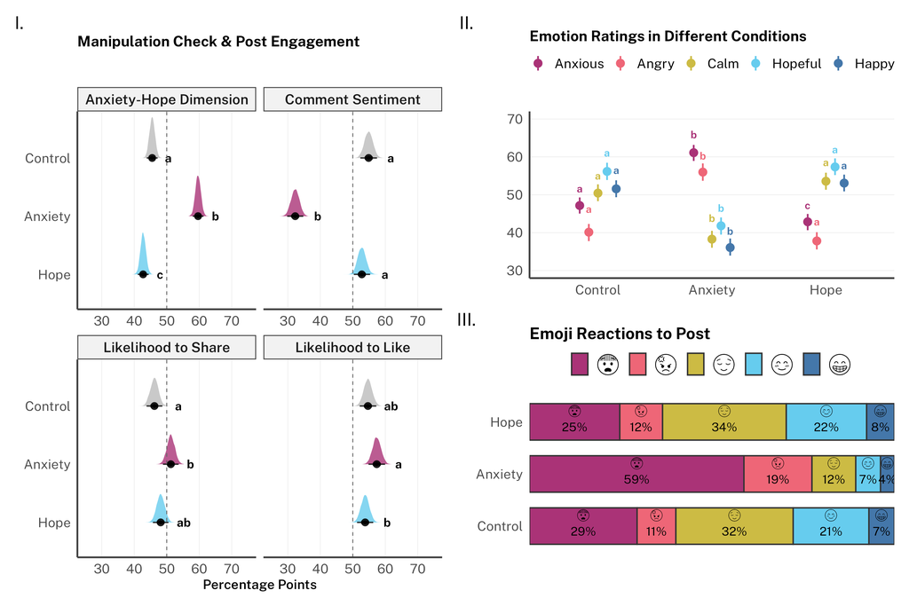

```r
manip_grid <- part1 | (part2 / part3)
manip_grid
```

```r
ggsave(here(figure_dir, "manip_grid.svg"), plot = manip_grid, width = 12, height = 8, web_fonts = svg_fonts)
```

### Emotion Differences in the Control Condition

Multivariate model of the five emotion ratings with residual correlations (`set_rescor(TRUE)`), as the ratings come from the same participants.

```r
er1_rc <- brm(
  data = df_mod,
  family = gaussian(),
  formula = bf(mvbind(Anxious, Angry, Hopeful, Happy, Calm) ~ exp_condition) +
    set_rescor(TRUE),
  prior = priors_er,
  sample_prior = "yes",
  init = "random",
  chains = chains,
  iter = iter,
  warmup = warmup,
  seed = bayes_seed,
  control = list(
    adapt_delta = adapt_delta,
    max_treedepth = max_treedepth
  )
)
```

```r
# Residual correlations between emotion ratings
tidy(er1_rc, parameters = "^rescor__", robust = TRUE,
     conf.method = "HPDinterval", rhat = TRUE, ess = TRUE) |>
  select(Term = term,
         Median = estimate,
         "95% HDI Lower" = conf.low,
         "95% HDI Upper" = conf.high,
         "R-hat" = rhat,
         ESS = ess) |>
  mutate(across(where(is.numeric), \(x) round(x, 3))) |>
  tt()
```

| Term | Median | 95% HDI Lower | 95% HDI Upper | R-hat | ESS |
| --- | --- | --- | --- | --- | --- |
| rescor__Anxious__Angry | 0.559 | 0.528 | 0.589 | 1 | 8942 |
| rescor__Anxious__Hopeful | -0.177 | -0.219 | -0.131 | 1 | 5965 |
| rescor__Angry__Hopeful | -0.349 | -0.388 | -0.310 | 1 | 6736 |
| rescor__Anxious__Happy | -0.187 | -0.232 | -0.144 | 1 | 6087 |
| rescor__Angry__Happy | -0.345 | -0.383 | -0.303 | 1 | 7053 |
| rescor__Hopeful__Happy | 0.750 | 0.729 | 0.769 | 1 | 7398 |
| rescor__Anxious__Calm | -0.211 | -0.253 | -0.167 | 1 | 5807 |
| rescor__Angry__Calm | -0.340 | -0.381 | -0.301 | 1 | 6675 |
| rescor__Hopeful__Calm | 0.710 | 0.687 | 0.732 | 1 | 7744 |
| rescor__Happy__Calm | 0.729 | 0.707 | 0.750 | 1 | 8730 |

```r
er1_rc_control_comps <- avg_predictions(
  er1_rc,
  newdata = datagrid(exp_condition = "control"),
  by = "group",
  hypothesis = ~ pairwise) |>
  as_tibble() |>
  select(Contrast = hypothesis,
         Median = estimate,
         "95% HDI Lower" = conf.low,
         "95% HDI Upper" = conf.high)

er1_rc_control_comps |> tt()
```

| Contrast | Median | 95% HDI Lower | 95% HDI Upper |
| --- | --- | --- | --- |
| (Anxious) - (Angry) | 0.07058 | 0.0489106 | 0.09055 |
| (Calm) - (Angry) | 0.10317 | 0.0673241 | 0.13969 |
| (Happy) - (Angry) | 0.11423 | 0.0783503 | 0.15171 |
| (Hopeful) - (Angry) | 0.16002 | 0.1224972 | 0.19735 |
| (Calm) - (Anxious) | 0.03276 | -0.0007696 | 0.06564 |
| (Happy) - (Anxious) | 0.04330 | 0.0111141 | 0.07859 |
| (Hopeful) - (Anxious) | 0.08966 | 0.0563205 | 0.12435 |
| (Happy) - (Calm) | 0.01078 | -0.0056478 | 0.02711 |
| (Hopeful) - (Calm) | 0.05688 | 0.0397552 | 0.07274 |
| (Hopeful) - (Happy) | 0.04596 | 0.0302738 | 0.06204 |

Paired t-tests as a frequentist check of the same contrasts.

```r
control_emotions_pairwise <- df_mod |>
  filter(exp_condition == "control") |>
  select(id, Anxious, Angry, Hopeful, Happy, Calm) |>
  pivot_longer(-id, names_to = "emotion", values_to = "rating") |>
  arrange(emotion, id) |>
  pairwise_t_test(
    rating ~ emotion,
    paired = TRUE,
    detailed = TRUE,
    p.adjust.method = "holm"
  )

control_emotions_pairwise |>
  select(`Group 1` = group1,
         `Group 2` = group2,
         Estimate = estimate,
         "95% CI Low" = conf.low,
         "95% CI High" = conf.high,
         p, p.adj, df) |>
  mutate(across(where(is.numeric), \(x) round(x, 3))) |>
  tt()
```

| Group 1 | Group 2 | Estimate | 95% CI Low | 95% CI High | p | p.adj | df |
| --- | --- | --- | --- | --- | --- | --- | --- |
| Angry | Anxious | -0.071 | -0.090 | -0.051 | 0.000 | 0.000 | 630 |
| Angry | Calm | -0.104 | -0.140 | -0.067 | 0.000 | 0.000 | 630 |
| Angry | Happy | -0.115 | -0.152 | -0.077 | 0.000 | 0.000 | 630 |
| Angry | Hopeful | -0.161 | -0.198 | -0.124 | 0.000 | 0.000 | 630 |
| Anxious | Calm | -0.033 | -0.067 | 0.000 | 0.053 | 0.107 | 630 |
| Anxious | Happy | -0.044 | -0.078 | -0.010 | 0.011 | 0.032 | 630 |
| Anxious | Hopeful | -0.090 | -0.124 | -0.056 | 0.000 | 0.000 | 630 |
| Calm | Happy | -0.011 | -0.027 | 0.005 | 0.172 | 0.172 | 630 |
| Calm | Hopeful | -0.057 | -0.074 | -0.040 | 0.000 | 0.000 | 630 |
| Happy | Hopeful | -0.046 | -0.061 | -0.031 | 0.000 | 0.000 | 630 |

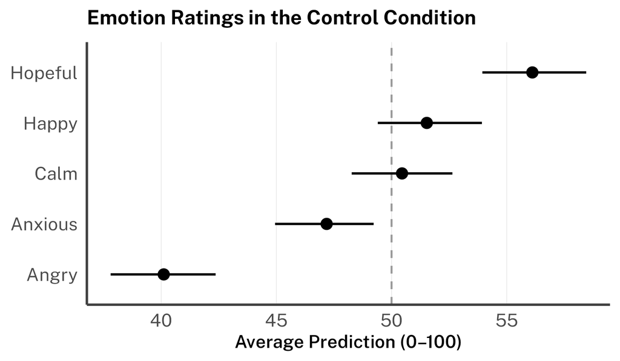

```r
er1_rc_control_fig <- tibble(exp_condition = "control") |>
  add_epred_draws(er1_rc, re_formula = NA) |>
  ungroup() |>
  mutate(
    .epred = .epred * 100,
    emotion = fct_reorder(.category, .epred, .fun = median)
  ) |>
  ggplot(aes(x = .epred, y = emotion)) +
  geom_vline(xintercept = 50, linetype = "dashed", color = "grey60") +
  stat_pointinterval(
    .width = 0.95,
    point_interval = "median_hdi",
    point_size = 3,
    linewidth = 2
  ) +
  labs(
    x = "Average Prediction (0–100)",
    y = NULL,
    title = "Emotion Ratings in the Control Condition"
  ) +
  theme_allround() +
  theme(
    plot.title = element_text(size = rel(1)),
    panel.grid.major.x = element_line(color = "grey90", linewidth = 0.2)
  )

er1_rc_control_fig
```

```r
ggsave(here(figure_dir, "control_emotions_ranked.svg"), plot = er1_rc_control_fig,
       width = 6, height = 3.5, web_fonts = svg_fonts)
```

### Heterogeneity in Emotional Effects

Moderation of the effects on the anxiety–hope dimension (ah models) and the five emotion ratings (er models) by age group, gender, living standard, age (continuous), and parental ideology.

#### Setup

```r
emotions <- c("Anxious", "Angry", "Hopeful", "Happy", "Calm")

# Moderation figures: anxiety–hope in black, emotions in the colors of the main text figure
emotion_levels <- c("Anxious", "Angry", "Calm", "Hopeful", "Happy")
outcome_colors <- c("Anxiety–Hope" = "black", emotion_colors)
outcome_shapes <- c("Anxiety–Hope" = 15, setNames(rep(16, 5), emotion_levels))
outcome_linewidths <- c("Anxiety–Hope" = 1.6, setNames(rep(0.9, 5), emotion_levels))

# Tidy marginaleffects output into a table with consistent column names
me_tidy <- \(x) x |>
  as_tibble() |>
  select(any_of(c("group", "contrast", "hypothesis", "exp_condition",
                  "age_group", "gender", "living_standard")),
         estimate, conf.low, conf.high) |>
  rename(any_of(c(
    Emotion = "group",
    Contrast = "contrast",
    "Moderator Contrast" = "hypothesis",
    Condition = "exp_condition",
    "Age Group" = "age_group",
    Gender = "gender",
    "Living Standard" = "living_standard"
  ))) |>
  rename(Median = estimate,
         "95% HDI Lower" = conf.low,
         "95% HDI Upper" = conf.high)
```

Living standard: collapse difficult and very difficult given the small number of respondents in “very difficult” (<5%)

```r
df_mod <- df_mod |>
  mutate(
    living_standard_orig = living_standard,
    living_standard = fct_collapse(
      living_standard_orig,
      Comfortable = levels(living_standard_orig)[1],
      Coping = levels(living_standard_orig)[2],
      Difficult = levels(living_standard_orig)[3:4]
    ) |> fct_rev(),
    living_standard_num = 5 - as.integer(living_standard_orig),
    living_standard_z = as.numeric(scale(living_standard_num))
  )

df_mod |> count(living_standard_orig, living_standard, living_standard_num, living_standard_z)
```

```
# A tibble: 4 × 5
  living_standard_orig                        living_standard living_standard_num living_standard_z     n
  <fct>                                       <fct>                         <dbl>             <dbl> <int>
1 Living comfortably on present income        Comfortable                       4             1.04    716
2 Coping on present income                    Coping                            3            -0.148   787
3 Finding it difficult on present income      Difficult                         2            -1.34    304
4 Finding it very difficult on present income Difficult                         1            -2.52     88
```

Age: standardise

```r
age_mean <- mean(df_mod$age)
age_sd <- sd(df_mod$age)
to_age_z <- \(x) (x - age_mean) / age_sd

df_mod <- df_mod |>
  mutate(age_z = to_age_z(age))

c(mean = age_mean, sd = age_sd)
```

```
  mean     sd
21.741  3.012
```

```r
df_mod |> summarise(across(c(age, age_z), list(min = min, max = max)))
```

```
# A tibble: 1 × 4
  age_min age_max age_z_min age_z_max
    <dbl>   <dbl>     <dbl>     <dbl>
1      16      26     -1.91      1.41
```

Parental ideology: standardise

```r
pi_mean <- mean(df_mod$parental_ideology, na.rm = TRUE)
pi_sd <- sd(df_mod$parental_ideology, na.rm = TRUE)
to_pi_z <- \(x) (x - pi_mean) / pi_sd

df_mod <- df_mod |>
  mutate(parental_ideology_z = to_pi_z(parental_ideology))

c(mean = pi_mean, sd = pi_sd)
```

```
 mean    sd
5.544 2.427
```

```r
df_mod |>
  summarise(n_missing = sum(is.na(parental_ideology)),
            prop_missing = mean(is.na(parental_ideology)),
            min = min(parental_ideology, na.rm = TRUE),
            max = max(parental_ideology, na.rm = TRUE))
```

```
# A tibble: 1 × 4
  n_missing prop_missing   min   max
      <int>        <dbl> <dbl> <dbl>
1       216        0.114     0    10
```

#### Age Group

##### Models

```r
ah2 <- brm(
  data = df_mod,
  family = gaussian(),
  formula = anxiety_hope_dim ~ exp_condition * age_group,
  prior = priors,
  sample_prior = "yes",
  init = "random",
  chains = chains,
  iter = iter,
  warmup = warmup,
  seed = bayes_seed,
  control = list(
    adapt_delta = adapt_delta,
    max_treedepth = max_treedepth),
  file = here(model_dir, "ah2.rds")
  )
```

```r
ah2_brms <- tidy(ah2, robust = TRUE, conf.method = "HPDinterval", rhat = TRUE, ess = TRUE) |>
  filter(effect == "fixed") |>
  mutate(term = case_when(
    term == "(Intercept)"                                ~ "Intercept",
    term == "exp_conditionhope"                         ~ "Hope (vs. Control)",
    term == "exp_conditionanxiety"                      ~ "Anxiety (vs. Control)",
    term == "age_group22M26years"                       ~ "Age Group 22-26 (vs. 16-21)",
    term == "exp_conditionhope:age_group22M26years"     ~ "Age Group x Hope",
    term == "exp_conditionanxiety:age_group22M26years"  ~ "Age Group x Anxiety",
    TRUE ~ term
  )) |>
  select(Term = term,
         Median = estimate,
         MAD = std.error,
         "95% HDI Lower" = conf.low,
         "95% HDI Upper" = conf.high,
         "R-hat" = rhat,
         ESS = ess)
```

```r
ah2_brms_table <- ah2_brms |>
  mutate(across(where(is.numeric), \(x) round(x, 3))) |>
  tt()

ah2_brms_table
```

| Term | Median | MAD | 95% HDI Lower | 95% HDI Upper | R-hat | ESS |
| --- | --- | --- | --- | --- | --- | --- |
| Intercept | 0.475 | 0.012 | 0.453 | 0.498 | 1.001 | 4428 |
| Hope (vs. Control) | -0.009 | 0.017 | -0.043 | 0.024 | 1.001 | 4521 |
| Anxiety (vs. Control) | 0.156 | 0.017 | 0.122 | 0.188 | 1.001 | 4695 |
| Age Group 22-26 (vs. 16-21) | -0.040 | 0.017 | -0.074 | -0.007 | 1.002 | 4156 |
| Age Group x Hope | -0.033 | 0.024 | -0.080 | 0.014 | 1.001 | 4333 |
| Age Group x Anxiety | -0.031 | 0.024 | -0.075 | 0.017 | 1.001 | 4209 |

```r
ah2_brms_table |>
  save_tt(here(table_dir, "ah2_brms_table.docx"), overwrite = TRUE)
```

```r
er2 <- brm(
  data = df_mod,
  family = gaussian(),
  formula = bf(mvbind(Anxious, Angry, Hopeful, Happy, Calm) ~ exp_condition * age_group) +
    set_rescor(FALSE),
  prior = priors_er,
  sample_prior = "yes",
  init = "random",
  chains = chains,
  iter = iter,
  warmup = warmup,
  seed = bayes_seed,
  control = list(
    adapt_delta = adapt_delta,
    max_treedepth = max_treedepth
  ),
  file = here(model_dir, "er2.rds")
)
```

```r
er2_brms_raw <- map(emotions, \(em) {
  tidy(er2, parameters = paste0("^b_", em), robust = TRUE,
       conf.method = "HPDinterval", rhat = TRUE, ess = TRUE) |>
    mutate(Outcome = em,
           term = str_remove(term, paste0("b_", em, "_")))
}) |>
  list_rbind()

er2_brms <- er2_brms_raw |>
  mutate(term = case_when(
    term == "(Intercept)"                                ~ "Intercept",
    term == "exp_conditionhope"                         ~ "Hope (vs. Control)",
    term == "exp_conditionanxiety"                      ~ "Anxiety (vs. Control)",
    term == "age_group22M26years"                       ~ "Age Group 22-26 (vs. 16-21)",
    term == "exp_conditionhope:age_group22M26years"     ~ "Age Group x Hope",
    term == "exp_conditionanxiety:age_group22M26years"  ~ "Age Group x Anxiety",
    TRUE ~ term
  )) |>
  select(Outcome, Term = term,
         Median = estimate,
         MAD = std.error,
         "95% HDI Lower" = conf.low,
         "95% HDI Upper" = conf.high,
         "R-hat" = rhat,
         ESS = ess)
```

```r
er2_brms_table <- er2_brms |>
  mutate(across(where(is.numeric), \(x) round(x, 3))) |>
  select(-Outcome) |>
  tt() |>
  group_tt(i = list(
    "Anxious" = 1,
    "Angry"   = 7,
    "Hopeful" = 13,
    "Happy"   = 19,
    "Calm"    = 25
  ))

er2_brms_table
```

| Term | Median | MAD | 95% HDI Lower | 95% HDI Upper | R-hat | ESS |
| --- | --- | --- | --- | --- | --- | --- |
| Anxious | Anxious | Anxious | Anxious | Anxious | Anxious | Anxious |
| Intercept | 0.471 | 0.015 | 0.441 | 0.501 | 1.000 | 5243 |
| Hope (vs. Control) | -0.036 | 0.022 | -0.079 | 0.007 | 1.000 | 6056 |
| Anxiety (vs. Control) | 0.156 | 0.022 | 0.113 | 0.198 | 1.000 | 6003 |
| Age Group 22-26 (vs. 16-21) | 0.002 | 0.021 | -0.038 | 0.046 | 1.000 | 4678 |
| Age Group x Hope | -0.013 | 0.031 | -0.075 | 0.047 | 1.001 | 5159 |
| Age Group x Anxiety | -0.033 | 0.031 | -0.093 | 0.027 | 1.000 | 5004 |
| Angry | Angry | Angry | Angry | Angry | Angry | Angry |
| Intercept | 0.395 | 0.016 | 0.364 | 0.426 | 1.000 | 5314 |
| Hope (vs. Control) | 0.013 | 0.023 | -0.031 | 0.059 | 1.001 | 5768 |
| Anxiety (vs. Control) | 0.180 | 0.023 | 0.137 | 0.225 | 1.000 | 5919 |
| Age Group 22-26 (vs. 16-21) | 0.013 | 0.023 | -0.032 | 0.057 | 1.000 | 4637 |
| Age Group x Hope | -0.071 | 0.032 | -0.134 | -0.007 | 1.000 | 4950 |
| Age Group x Anxiety | -0.044 | 0.032 | -0.108 | 0.020 | 1.000 | 5029 |
| Hopeful | Hopeful | Hopeful | Hopeful | Hopeful | Hopeful | Hopeful |
| Intercept | 0.521 | 0.016 | 0.491 | 0.551 | 1.000 | 5017 |
| Hope (vs. Control) | -0.017 | 0.022 | -0.062 | 0.027 | 1.000 | 5412 |
| Anxiety (vs. Control) | -0.156 | 0.022 | -0.198 | -0.112 | 1.000 | 5399 |
| Age Group 22-26 (vs. 16-21) | 0.082 | 0.022 | 0.039 | 0.125 | 1.000 | 4403 |
| Age Group x Hope | 0.052 | 0.031 | -0.008 | 0.114 | 1.000 | 4445 |
| Age Group x Anxiety | 0.026 | 0.032 | -0.037 | 0.086 | 1.001 | 4828 |
| Happy | Happy | Happy | Happy | Happy | Happy | Happy |
| Intercept | 0.464 | 0.016 | 0.435 | 0.494 | 1.001 | 5370 |
| Hope (vs. Control) | 0.010 | 0.023 | -0.035 | 0.054 | 1.000 | 5789 |
| Anxiety (vs. Control) | -0.142 | 0.022 | -0.186 | -0.099 | 1.000 | 5858 |
| Age Group 22-26 (vs. 16-21) | 0.106 | 0.022 | 0.061 | 0.149 | 1.001 | 4766 |
| Age Group x Hope | 0.003 | 0.032 | -0.059 | 0.065 | 1.000 | 5085 |
| Age Group x Anxiety | -0.026 | 0.032 | -0.089 | 0.035 | 1.000 | 5151 |
| Calm | Calm | Calm | Calm | Calm | Calm | Calm |
| Intercept | 0.453 | 0.016 | 0.424 | 0.485 | 1.000 | 4991 |
| Hope (vs. Control) | 0.020 | 0.022 | -0.025 | 0.063 | 1.000 | 5796 |
| Anxiety (vs. Control) | -0.114 | 0.022 | -0.157 | -0.071 | 1.000 | 5331 |
| Age Group 22-26 (vs. 16-21) | 0.106 | 0.022 | 0.063 | 0.150 | 1.000 | 4789 |
| Age Group x Hope | 0.015 | 0.031 | -0.045 | 0.080 | 1.001 | 5212 |
| Age Group x Anxiety | -0.016 | 0.031 | -0.080 | 0.042 | 1.000 | 4940 |

```r
er2_brms_table |>
  save_tt(here(table_dir, "er2_brms_table.docx"), overwrite = TRUE)
```

##### 1. Association across Conditions

```r
ah2_mod_comps <- avg_comparisons(
  ah2,
  newdata = datagrid(exp_condition = unique, age_group = unique),
  variables = list(age_group = "pairwise")) |>
  me_tidy()

ah2_mod_comps |> tt()
```

| Contrast | Median | 95% HDI Lower | 95% HDI Upper |
| --- | --- | --- | --- |
| 22-26 years - 16-21 years | -0.06108 | -0.0806 | -0.04265 |

##### 2. Moderation of Treatment Effects

```r
ah2_comp_diffs <- avg_comparisons(
  ah2,
  newdata = datagrid(exp_condition = unique, age_group = unique),
  variables = list(exp_condition = "pairwise"),
  by = "age_group",
  hypothesis = difference ~ pairwise | contrast) |>
  me_tidy()

ah2_comp_diffs |> tt()
```

| Contrast | Moderator Contrast | Median | 95% HDI Lower | 95% HDI Upper |
| --- | --- | --- | --- | --- |
| anxiety - control | (22-26 years) - (16-21 years) | -0.030527 | -0.07530 | 0.01733 |
| anxiety - hope | (22-26 years) - (16-21 years) | 0.002917 | -0.04418 | 0.04841 |
| hope - control | (22-26 years) - (16-21 years) | -0.032958 | -0.08042 | 0.01354 |

Supporting: condition contrasts within each age group

```r
ah2_comps <- avg_comparisons(
  ah2,
  newdata = datagrid(exp_condition = unique, age_group = unique),
  variables = list(exp_condition = "pairwise"),
  by = "age_group") |>
  me_tidy()

ah2_comps |> tt()
```

| Contrast | Age Group | Median | 95% HDI Lower | 95% HDI Upper |
| --- | --- | --- | --- | --- |
| anxiety - control | 16-21 years | 0.155806 | 0.12210 | 0.187741 |
| anxiety - hope | 16-21 years | 0.165324 | 0.13362 | 0.199792 |
| hope - control | 16-21 years | -0.009348 | -0.04264 | 0.023562 |
| anxiety - control | 22-26 years | 0.125763 | 0.09108 | 0.158055 |
| anxiety - hope | 22-26 years | 0.168255 | 0.13260 | 0.198754 |
| hope - control | 22-26 years | -0.042111 | -0.07494 | -0.009083 |

##### 3. Anxiety–Hope and Emotion Ratings

Model predictions (median and 95% HDI) by condition and age group; black squares show the anxiety–hope dimension.

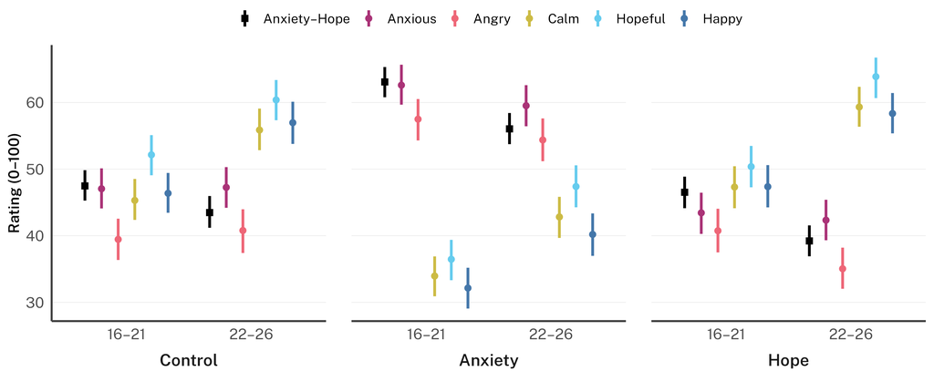

```r
ag_preds <- bind_rows(
  predictions(ah2, newdata = datagrid(exp_condition = unique, age_group = unique)) |>
    as_tibble() |>
    mutate(outcome = "Anxiety–Hope"),
  predictions(er2, newdata = datagrid(exp_condition = unique, age_group = unique)) |>
    as_tibble() |>
    mutate(outcome = as.character(group))
) |>
  mutate(
    across(c(estimate, conf.low, conf.high), \(x) x * 100),
    outcome = factor(outcome, levels = names(outcome_colors)),
    exp_condition = factor(exp_condition, levels = c("control", "anxiety", "hope"),
                           labels = c("Control", "Anxiety", "Hope"))
  )

ag_fig <- ag_preds |>
  ggplot(aes(x = age_group, y = estimate, ymin = conf.low, ymax = conf.high,
             color = outcome, shape = outcome)) +
  geom_pointrange(position = position_dodge(width = 0.8), size = 0.5, linewidth = 1.1) +
  facet_grid(. ~ exp_condition, switch = "x") +
  scale_x_discrete(labels = c("16-21 years" = "16–21", "22-26 years" = "22–26")) +
  scale_color_manual(values = outcome_colors, name = NULL) +
  scale_shape_manual(values = outcome_shapes, name = NULL) +
  guides(color = guide_legend(nrow = 1), shape = guide_legend(nrow = 1)) +
  labs(x = NULL, y = "Rating (0–100)") +
  theme_allround() +
  theme(
    # Strips below the x labels act as a nested condition axis
    strip.placement = "outside",
    strip.background = element_blank(),
    panel.spacing.x = unit(1.5, "lines"),
    panel.grid.major.y = element_line(color = "grey90", linewidth = 0.2)
  )

ag_fig
```

```r
ggsave(here(figure_dir, "moderation_age_group.svg"), plot = ag_fig,
       width = 11, height = 4.5, web_fonts = svg_fonts)
```

```r
er2_mod_comps <- avg_comparisons(
  er2,
  newdata = datagrid(exp_condition = unique, age_group = unique),
  variables = list(age_group = "pairwise"),
  by = "group") |>
  me_tidy()

er2_mod_comps |> tt()
```

| Emotion | Contrast | Median | 95% HDI Lower | 95% HDI Upper |
| --- | --- | --- | --- | --- |
| Angry | 22-26 years - 16-21 years | -0.02494 | -0.05161 | 0.0003439 |
| Anxious | 22-26 years - 16-21 years | -0.01317 | -0.03852 | 0.0108519 |
| Calm | 22-26 years - 16-21 years | 0.10468 | 0.07854 | 0.1294945 |
| Happy | 22-26 years - 16-21 years | 0.09885 | 0.07422 | 0.1245551 |
| Hopeful | 22-26 years - 16-21 years | 0.10863 | 0.08226 | 0.1330728 |

```r
er2_comp_diffs <- avg_comparisons(
  er2,
  newdata = datagrid(exp_condition = unique, age_group = unique),
  variables = list(exp_condition = "pairwise"),
  by = c("group", "age_group"),
  hypothesis = difference ~ pairwise | group + contrast) |>
  me_tidy()

er2_comp_diffs |> tt()
```

| Emotion | Contrast | Moderator Contrast | Median | 95% HDI Lower | 95% HDI Upper |
| --- | --- | --- | --- | --- | --- |
| Angry | anxiety - control | (22-26 years) - (16-21 years) | -0.044363 | -0.107988 | 0.019788 |
| Angry | anxiety - hope | (22-26 years) - (16-21 years) | 0.026072 | -0.037168 | 0.089258 |
| Angry | hope - control | (22-26 years) - (16-21 years) | -0.070622 | -0.134142 | -0.007441 |
| Anxious | anxiety - control | (22-26 years) - (16-21 years) | -0.033192 | -0.093199 | 0.026861 |
| Anxious | anxiety - hope | (22-26 years) - (16-21 years) | -0.020161 | -0.082510 | 0.040066 |
| Anxious | hope - control | (22-26 years) - (16-21 years) | -0.012907 | -0.075041 | 0.046541 |
| Calm | anxiety - control | (22-26 years) - (16-21 years) | -0.016240 | -0.080500 | 0.041724 |
| Calm | anxiety - hope | (22-26 years) - (16-21 years) | -0.031671 | -0.094678 | 0.026709 |
| Calm | hope - control | (22-26 years) - (16-21 years) | 0.014830 | -0.044558 | 0.079989 |
| Happy | anxiety - control | (22-26 years) - (16-21 years) | -0.025579 | -0.088851 | 0.035043 |
| Happy | anxiety - hope | (22-26 years) - (16-21 years) | -0.029002 | -0.088175 | 0.035196 |
| Happy | hope - control | (22-26 years) - (16-21 years) | 0.003346 | -0.058595 | 0.064518 |
| Hopeful | anxiety - control | (22-26 years) - (16-21 years) | 0.026451 | -0.036505 | 0.085954 |
| Hopeful | anxiety - hope | (22-26 years) - (16-21 years) | -0.025884 | -0.087077 | 0.035310 |
| Hopeful | hope - control | (22-26 years) - (16-21 years) | 0.052369 | -0.007782 | 0.114088 |

#### Gender

##### Models

```r
ah3 <- brm(
  data = df_mod,
  family = gaussian(),
  formula = anxiety_hope_dim ~ exp_condition * gender,
  prior = priors,
  sample_prior = "yes",
  init = "random",
  chains = chains,
  iter = iter,
  warmup = warmup,
  seed = bayes_seed,
  control = list(
    adapt_delta = adapt_delta,
    max_treedepth = max_treedepth),
  file = here(model_dir, "ah3.rds")
  )
```

```r
ah3_brms <- tidy(ah3, robust = TRUE, conf.method = "HPDinterval", rhat = TRUE, ess = TRUE) |>
  filter(effect == "fixed") |>
  mutate(term = case_when(
    term == "(Intercept)"                          ~ "Intercept",
    term == "exp_conditionhope"                    ~ "Hope (vs. Control)",
    term == "exp_conditionanxiety"                 ~ "Anxiety (vs. Control)",
    term == "genderfemale"                         ~ "Women (vs. Men)",
    term == "genderother"                          ~ "Other (vs. Men)",
    term == "exp_conditionhope:genderfemale"       ~ "Women x Hope",
    term == "exp_conditionanxiety:genderfemale"    ~ "Women x Anxiety",
    term == "exp_conditionhope:genderother"        ~ "Other x Hope",
    term == "exp_conditionanxiety:genderother"     ~ "Other x Anxiety",
    TRUE ~ term
  )) |>
  select(Term = term,
         Median = estimate,
         MAD = std.error,
         "95% HDI Lower" = conf.low,
         "95% HDI Upper" = conf.high,
         "R-hat" = rhat,
         ESS = ess)
```

```r
ah3_brms_table <- ah3_brms |>
  mutate(across(where(is.numeric), \(x) round(x, 3))) |>
  tt()

ah3_brms_table
```

| Term | Median | MAD | 95% HDI Lower | 95% HDI Upper | R-hat | ESS |
| --- | --- | --- | --- | --- | --- | --- |
| Intercept | 0.440 | 0.013 | 0.415 | 0.464 | 1.000 | 5194 |
| Hope (vs. Control) | -0.014 | 0.017 | -0.048 | 0.019 | 1.000 | 5027 |
| Anxiety (vs. Control) | 0.116 | 0.017 | 0.081 | 0.150 | 1.000 | 5244 |
| Women (vs. Men) | 0.026 | 0.017 | -0.006 | 0.060 | 1.000 | 4622 |
| Other (vs. Men) | 0.080 | 0.117 | -0.142 | 0.308 | 1.001 | 5078 |
| Women x Hope | -0.024 | 0.023 | -0.069 | 0.023 | 1.000 | 4648 |
| Women x Anxiety | 0.053 | 0.024 | 0.007 | 0.099 | 1.000 | 4856 |
| Other x Hope | -0.076 | 0.147 | -0.367 | 0.211 | 1.001 | 5316 |
| Other x Anxiety | 0.072 | 0.149 | -0.225 | 0.374 | 1.001 | 5722 |

```r
ah3_brms_table |>
  save_tt(here(table_dir, "ah3_brms_table.docx"), overwrite = TRUE)
```

```r
er3 <- brm(
  data = df_mod,
  family = gaussian(),
  formula = bf(mvbind(Anxious, Angry, Hopeful, Happy, Calm) ~ exp_condition * gender) +
    set_rescor(FALSE),
  prior = priors_er,
  sample_prior = "yes",
  init = "random",
  chains = chains,
  iter = iter,
  warmup = warmup,
  seed = bayes_seed,
  control = list(
    adapt_delta = adapt_delta,
    max_treedepth = max_treedepth
  ),
  file = here(model_dir, "er3.rds")
)
```

```r
er3_brms_raw <- map(emotions, \(em) {
  tidy(er3, parameters = paste0("^b_", em), robust = TRUE,
       conf.method = "HPDinterval", rhat = TRUE, ess = TRUE) |>
    mutate(Outcome = em,
           term = str_remove(term, paste0("b_", em, "_")))
}) |>
  list_rbind()

er3_brms <- er3_brms_raw |>
  mutate(term = case_when(
    term == "(Intercept)"                              ~ "Intercept",
    term == "exp_conditionhope"                        ~ "Hope (vs. Control)",
    term == "exp_conditionanxiety"                     ~ "Anxiety (vs. Control)",
    term == "genderfemale"                             ~ "Women (vs. Men)",
    term == "genderother"                              ~ "Other (vs. Men)",
    term == "exp_conditionhope:genderfemale"           ~ "Women x Hope",
    term == "exp_conditionanxiety:genderfemale"        ~ "Women x Anxiety",
    term == "exp_conditionhope:genderother"            ~ "Other x Hope",
    term == "exp_conditionanxiety:genderother"         ~ "Other x Anxiety",
    TRUE ~ term
  )) |>
  select(Outcome, Term = term,
         Median = estimate,
         MAD = std.error,
         "95% HDI Lower" = conf.low,
         "95% HDI Upper" = conf.high,
         "R-hat" = rhat,
         ESS = ess)
```

```r
er3_brms_table <- er3_brms |>
  mutate(across(where(is.numeric), \(x) round(x, 3))) |>
  select(-Outcome) |>
  tt() |>
  group_tt(i = list(
    "Anxious" = 1,
    "Angry"   = 10,
    "Hopeful" = 19,
    "Happy"   = 28,
    "Calm"    = 37
  ))

er3_brms_table
```

| Term | Median | MAD | 95% HDI Lower | 95% HDI Upper | R-hat | ESS |
| --- | --- | --- | --- | --- | --- | --- |
| Anxious | Anxious | Anxious | Anxious | Anxious | Anxious | Anxious |
| Intercept | 0.443 | 0.016 | 0.410 | 0.474 | 1.000 | 6023 |
| Hope (vs. Control) | -0.015 | 0.022 | -0.059 | 0.029 | 1.000 | 6071 |
| Anxiety (vs. Control) | 0.127 | 0.022 | 0.084 | 0.172 | 1.000 | 6027 |
| Women (vs. Men) | 0.050 | 0.022 | 0.008 | 0.093 | 1.000 | 4965 |
| Other (vs. Men) | 0.069 | 0.134 | -0.201 | 0.329 | 1.000 | 7432 |
| Women x Hope | -0.049 | 0.031 | -0.107 | 0.014 | 1.000 | 5550 |
| Women x Anxiety | 0.030 | 0.031 | -0.030 | 0.091 | 1.001 | 5486 |
| Other x Hope | -0.127 | 0.175 | -0.456 | 0.226 | 1.001 | 8262 |
| Other x Anxiety | 0.013 | 0.182 | -0.324 | 0.382 | 1.000 | 8540 |
| Angry | Angry | Angry | Angry | Angry | Angry | Angry |
| Intercept | 0.400 | 0.018 | 0.365 | 0.433 | 1.001 | 6686 |
| Hope (vs. Control) | -0.010 | 0.024 | -0.058 | 0.036 | 1.001 | 6900 |
| Anxiety (vs. Control) | 0.137 | 0.024 | 0.093 | 0.187 | 1.001 | 6688 |
| Women (vs. Men) | 0.001 | 0.023 | -0.041 | 0.049 | 1.001 | 6188 |
| Other (vs. Men) | 0.065 | 0.141 | -0.219 | 0.345 | 1.000 | 6918 |
| Women x Hope | -0.026 | 0.033 | -0.089 | 0.041 | 1.001 | 6518 |
| Women x Anxiety | 0.043 | 0.033 | -0.020 | 0.108 | 1.001 | 6606 |
| Other x Hope | -0.031 | 0.183 | -0.406 | 0.315 | 1.000 | 7630 |
| Other x Anxiety | -0.109 | 0.194 | -0.460 | 0.284 | 1.000 | 7996 |
| Hopeful | Hopeful | Hopeful | Hopeful | Hopeful | Hopeful | Hopeful |
| Intercept | 0.562 | 0.017 | 0.529 | 0.595 | 1.001 | 6371 |
| Hope (vs. Control) | 0.014 | 0.023 | -0.034 | 0.059 | 1.000 | 6525 |
| Anxiety (vs. Control) | -0.103 | 0.023 | -0.149 | -0.057 | 1.000 | 7120 |
| Women (vs. Men) | -0.001 | 0.023 | -0.045 | 0.044 | 1.000 | 6015 |
| Other (vs. Men) | -0.087 | 0.143 | -0.370 | 0.191 | 1.001 | 6080 |
| Women x Hope | -0.002 | 0.032 | -0.066 | 0.061 | 1.000 | 6480 |
| Women x Anxiety | -0.077 | 0.032 | -0.142 | -0.014 | 1.000 | 6434 |
| Other x Hope | 0.013 | 0.181 | -0.341 | 0.374 | 1.001 | 6784 |
| Other x Anxiety | -0.125 | 0.185 | -0.477 | 0.265 | 1.002 | 7336 |
| Happy | Happy | Happy | Happy | Happy | Happy | Happy |
| Intercept | 0.521 | 0.017 | 0.488 | 0.554 | 1.000 | 6299 |
| Hope (vs. Control) | 0.013 | 0.024 | -0.033 | 0.059 | 1.001 | 6584 |
| Anxiety (vs. Control) | -0.120 | 0.024 | -0.167 | -0.075 | 1.000 | 6432 |
| Women (vs. Men) | -0.009 | 0.023 | -0.057 | 0.035 | 1.000 | 5842 |
| Other (vs. Men) | -0.090 | 0.148 | -0.382 | 0.188 | 1.000 | 7275 |
| Women x Hope | 0.005 | 0.034 | -0.059 | 0.071 | 1.000 | 5956 |
| Women x Anxiety | -0.071 | 0.033 | -0.135 | -0.008 | 1.000 | 5686 |
| Other x Hope | -0.027 | 0.187 | -0.395 | 0.333 | 1.000 | 7944 |
| Other x Anxiety | 0.003 | 0.195 | -0.375 | 0.384 | 1.000 | 8440 |
| Calm | Calm | Calm | Calm | Calm | Calm | Calm |
| Intercept | 0.519 | 0.017 | 0.487 | 0.552 | 1.000 | 6303 |
| Hope (vs. Control) | 0.042 | 0.023 | -0.004 | 0.086 | 1.000 | 6549 |
| Anxiety (vs. Control) | -0.083 | 0.023 | -0.127 | -0.038 | 1.000 | 6437 |
| Women (vs. Men) | -0.025 | 0.023 | -0.068 | 0.020 | 1.000 | 6025 |
| Other (vs. Men) | -0.144 | 0.142 | -0.438 | 0.122 | 1.001 | 7218 |
| Women x Hope | -0.027 | 0.032 | -0.089 | 0.034 | 1.001 | 6389 |
| Women x Anxiety | -0.081 | 0.031 | -0.145 | -0.022 | 1.000 | 6026 |
| Other x Hope | 0.055 | 0.178 | -0.299 | 0.416 | 1.000 | 7797 |
| Other x Anxiety | -0.004 | 0.194 | -0.362 | 0.384 | 1.000 | 7808 |

```r
er3_brms_table |>
  save_tt(here(table_dir, "er3_brms_table.docx"), overwrite = TRUE)
```

##### 1. Association across Conditions

```r
ah3_mod_comps <- avg_comparisons(
  ah3,
  newdata = datagrid(exp_condition = unique, gender = unique),
  variables = list(gender = "pairwise")) |>
  me_tidy()

ah3_mod_comps |> tt()
```

| Contrast | Median | 95% HDI Lower | 95% HDI Upper |
| --- | --- | --- | --- |
| female - male | 0.03579 | 0.01526 | 0.05477 |
| other - female | 0.04179 | -0.07735 | 0.16858 |
| other - male | 0.07773 | -0.04335 | 0.20335 |

##### 2. Moderation of Treatment Effects

```r
ah3_comp_diffs <- avg_comparisons(
  ah3,
  newdata = datagrid(exp_condition = unique, gender = unique),
  variables = list(exp_condition = "pairwise"),
  by = "gender",
  hypothesis = difference ~ pairwise | contrast) |>
  me_tidy()

ah3_comp_diffs |> tt()
```

| Contrast | Moderator Contrast | Median | 95% HDI Lower | 95% HDI Upper |
| --- | --- | --- | --- | --- |
| anxiety - control | (female) - (male) | 0.05336 | 0.006991 | 0.09889 |
| anxiety - control | (other) - (male) | 0.07206 | -0.225464 | 0.37393 |
| anxiety - control | (other) - (female) | 0.02034 | -0.271215 | 0.32186 |
| anxiety - hope | (female) - (male) | 0.07714 | 0.028360 | 0.12291 |
| anxiety - hope | (other) - (male) | 0.14723 | -0.132041 | 0.42049 |
| anxiety - hope | (other) - (female) | 0.07134 | -0.204767 | 0.34968 |
| hope - control | (female) - (male) | -0.02380 | -0.069011 | 0.02313 |
| hope - control | (other) - (male) | -0.07583 | -0.367168 | 0.21102 |
| hope - control | (other) - (female) | -0.05284 | -0.336966 | 0.23644 |

Supporting: condition contrasts within each gender

```r
ah3_comps <- avg_comparisons(
  ah3,
  newdata = datagrid(exp_condition = unique, gender = unique),
  variables = list(exp_condition = "pairwise"),
  by = "gender") |>
  me_tidy()

ah3_comps |> tt()
```

| Contrast | Gender | Median | 95% HDI Lower | 95% HDI Upper |
| --- | --- | --- | --- | --- |
| anxiety - control | male | 0.11580 | 0.08133 | 0.149765 |
| anxiety - hope | male | 0.12970 | 0.09722 | 0.163802 |
| hope - control | male | -0.01400 | -0.04801 | 0.019198 |
| anxiety - control | female | 0.16901 | 0.13506 | 0.200999 |
| anxiety - hope | female | 0.20678 | 0.17288 | 0.239113 |
| hope - control | female | -0.03765 | -0.07290 | -0.007448 |
| anxiety - control | other | 0.18832 | -0.10037 | 0.489052 |
| anxiety - hope | other | 0.27688 | 0.01133 | 0.560852 |
| hope - control | other | -0.09006 | -0.37412 | 0.195380 |

##### 3. Anxiety–Hope and Emotion Ratings

Model predictions (median and 95% HDI) by condition and gender (“other” is included in the models but not shown); black squares show the anxiety–hope dimension.

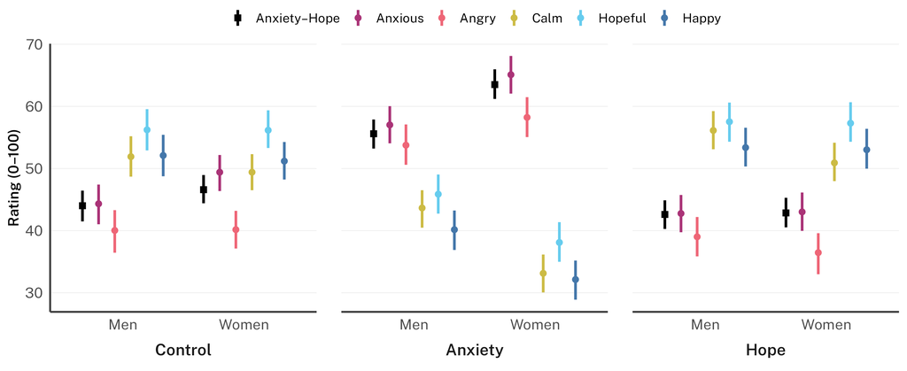

```r
gender_preds <- bind_rows(
  predictions(ah3, newdata = datagrid(exp_condition = unique, gender = c("male", "female"))) |>
    as_tibble() |>
    mutate(outcome = "Anxiety–Hope"),
  predictions(er3, newdata = datagrid(exp_condition = unique, gender = c("male", "female"))) |>
    as_tibble() |>
    mutate(outcome = as.character(group))
) |>
  mutate(
    across(c(estimate, conf.low, conf.high), \(x) x * 100),
    outcome = factor(outcome, levels = names(outcome_colors)),
    exp_condition = factor(exp_condition, levels = c("control", "anxiety", "hope"),
                           labels = c("Control", "Anxiety", "Hope"))
  )

gender_fig <- gender_preds |>
  ggplot(aes(x = gender, y = estimate, ymin = conf.low, ymax = conf.high,
             color = outcome, shape = outcome)) +
  geom_pointrange(position = position_dodge(width = 0.8), size = 0.5, linewidth = 1.1) +
  facet_grid(. ~ exp_condition, switch = "x") +
  scale_x_discrete(labels = c("male" = "Men", "female" = "Women")) +
  scale_color_manual(values = outcome_colors, name = NULL) +
  scale_shape_manual(values = outcome_shapes, name = NULL) +
  guides(color = guide_legend(nrow = 1), shape = guide_legend(nrow = 1)) +
  labs(x = NULL, y = "Rating (0–100)") +
  theme_allround() +
  theme(
    # Strips below the x labels act as a nested condition axis
    strip.placement = "outside",
    strip.background = element_blank(),
    panel.spacing.x = unit(1.5, "lines"),
    panel.grid.major.y = element_line(color = "grey90", linewidth = 0.2)
  )

gender_fig
```

```r
ggsave(here(figure_dir, "moderation_gender.svg"), plot = gender_fig,
       width = 11, height = 4.5, web_fonts = svg_fonts)
```

```r
er3_mod_comps <- avg_comparisons(
  er3,
  newdata = datagrid(exp_condition = unique, gender = unique),
  variables = list(gender = "pairwise"),
  by = "group") |>
  me_tidy()

er3_mod_comps |> tt()
```

| Emotion | Contrast | Median | 95% HDI Lower | 95% HDI Upper |
| --- | --- | --- | --- | --- |
| Angry | female - male | 0.006915 | -0.01839 | 0.034808 |
| Angry | other - female | 0.010624 | -0.15267 | 0.171421 |
| Angry | other - male | 0.017452 | -0.13894 | 0.190204 |
| Anxious | female - male | 0.044498 | 0.01995 | 0.069082 |
| Anxious | other - female | -0.013877 | -0.16892 | 0.133237 |
| Anxious | other - male | 0.031027 | -0.11584 | 0.183489 |
| Calm | female - male | -0.060827 | -0.08558 | -0.034944 |
| Calm | other - female | -0.066280 | -0.22573 | 0.091768 |
| Calm | other - male | -0.127361 | -0.27839 | 0.040794 |
| Happy | female - male | -0.030694 | -0.05584 | -0.004353 |
| Happy | other - female | -0.068400 | -0.22963 | 0.098170 |
| Happy | other - male | -0.099523 | -0.26143 | 0.067109 |
| Hopeful | female - male | -0.026900 | -0.05273 | -0.001596 |
| Hopeful | other - female | -0.095859 | -0.25393 | 0.070084 |
| Hopeful | other - male | -0.123612 | -0.28151 | 0.043289 |

```r
er3_comp_diffs <- avg_comparisons(
  er3,
  newdata = datagrid(exp_condition = unique, gender = unique),
  variables = list(exp_condition = "pairwise"),
  by = c("group", "gender"),
  hypothesis = difference ~ pairwise | group + contrast) |>
  me_tidy()

er3_comp_diffs |> tt()
```

| Emotion | Contrast | Moderator Contrast | Median | 95% HDI Lower | 95% HDI Upper |
| --- | --- | --- | --- | --- | --- |
| Angry | anxiety - control | (female) - (male) | 4.319e-02 | -0.020425 | 0.108463 |
| Angry | anxiety - control | (other) - (male) | -1.086e-01 | -0.459667 | 0.284353 |
| Angry | anxiety - control | (other) - (female) | -1.534e-01 | -0.523295 | 0.228277 |
| Angry | anxiety - hope | (female) - (male) | 7.009e-02 | 0.005535 | 0.134598 |
| Angry | anxiety - hope | (other) - (male) | -7.651e-02 | -0.446146 | 0.283381 |
| Angry | anxiety - hope | (other) - (female) | -1.474e-01 | -0.517873 | 0.217684 |
| Angry | hope - control | (female) - (male) | -2.641e-02 | -0.089320 | 0.040589 |
| Angry | hope - control | (other) - (male) | -3.120e-02 | -0.405923 | 0.315163 |
| Angry | hope - control | (other) - (female) | -3.779e-03 | -0.363930 | 0.354664 |
| Anxious | anxiety - control | (female) - (male) | 2.967e-02 | -0.029775 | 0.091054 |
| Anxious | anxiety - control | (other) - (male) | 1.266e-02 | -0.323890 | 0.381593 |
| Anxious | anxiety - control | (other) - (female) | -1.759e-02 | -0.358404 | 0.348163 |
| Anxious | anxiety - hope | (female) - (male) | 7.809e-02 | 0.015411 | 0.136654 |
| Anxious | anxiety - hope | (other) - (male) | 1.437e-01 | -0.207072 | 0.510838 |
| Anxious | anxiety - hope | (other) - (female) | 6.637e-02 | -0.290566 | 0.429507 |
| Anxious | hope - control | (female) - (male) | -4.853e-02 | -0.107000 | 0.013538 |
| Anxious | hope - control | (other) - (male) | -1.270e-01 | -0.455675 | 0.226466 |
| Anxious | hope - control | (other) - (female) | -7.898e-02 | -0.432519 | 0.249774 |
| Calm | anxiety - control | (female) - (male) | -8.053e-02 | -0.145441 | -0.021581 |
| Calm | anxiety - control | (other) - (male) | -4.362e-03 | -0.362050 | 0.384421 |
| Calm | anxiety - control | (other) - (female) | 7.470e-02 | -0.296676 | 0.450561 |
| Calm | anxiety - hope | (female) - (male) | -5.358e-02 | -0.114700 | 0.005626 |
| Calm | anxiety - hope | (other) - (male) | -5.531e-02 | -0.417791 | 0.303286 |
| Calm | anxiety - hope | (other) - (female) | 9.393e-05 | -0.378576 | 0.351328 |
| Calm | hope - control | (female) - (male) | -2.659e-02 | -0.089222 | 0.034372 |
| Calm | hope - control | (other) - (male) | 5.488e-02 | -0.298772 | 0.415902 |
| Calm | hope - control | (other) - (female) | 8.006e-02 | -0.305472 | 0.414874 |
| Happy | anxiety - control | (female) - (male) | -7.136e-02 | -0.134644 | -0.008159 |
| Happy | anxiety - control | (other) - (male) | 2.985e-03 | -0.375157 | 0.383940 |
| Happy | anxiety - control | (other) - (female) | 7.423e-02 | -0.298550 | 0.469872 |
| Happy | anxiety - hope | (female) - (male) | -7.633e-02 | -0.139054 | -0.013587 |
| Happy | anxiety - hope | (other) - (male) | 2.886e-02 | -0.329716 | 0.395098 |
| Happy | anxiety - hope | (other) - (female) | 1.047e-01 | -0.247168 | 0.473357 |
| Happy | hope - control | (female) - (male) | 5.424e-03 | -0.058565 | 0.070607 |
| Happy | hope - control | (other) - (male) | -2.701e-02 | -0.395495 | 0.332887 |
| Happy | hope - control | (other) - (female) | -3.186e-02 | -0.410567 | 0.325890 |
| Hopeful | anxiety - control | (female) - (male) | -7.717e-02 | -0.141732 | -0.013825 |
| Hopeful | anxiety - control | (other) - (male) | -1.252e-01 | -0.476567 | 0.264617 |
| Hopeful | anxiety - control | (other) - (female) | -4.894e-02 | -0.410458 | 0.338653 |
| Hopeful | anxiety - hope | (female) - (male) | -7.594e-02 | -0.137635 | -0.012964 |
| Hopeful | anxiety - hope | (other) - (male) | -1.403e-01 | -0.489084 | 0.230475 |
| Hopeful | anxiety - hope | (other) - (female) | -6.545e-02 | -0.417911 | 0.303709 |
| Hopeful | hope - control | (female) - (male) | -1.754e-03 | -0.066395 | 0.061254 |
| Hopeful | hope - control | (other) - (male) | 1.292e-02 | -0.341190 | 0.374172 |
| Hopeful | hope - control | (other) - (female) | 1.518e-02 | -0.341749 | 0.376922 |

#### Living Standard

##### Models

```r
ah4 <- brm(
  data = df_mod,
  family = gaussian(),
  formula = anxiety_hope_dim ~ exp_condition * living_standard,
  prior = priors,
  sample_prior = "yes",
  init = "random",
  chains = chains,
  iter = iter,
  warmup = warmup,
  seed = bayes_seed,
  control = list(
    adapt_delta = adapt_delta,
    max_treedepth = max_treedepth),
  file = here(model_dir, "ah4.rds")
  )
```

```r
ah4_brms <- tidy(ah4, robust = TRUE, conf.method = "HPDinterval", rhat = TRUE, ess = TRUE) |>
  filter(effect == "fixed") |>
  mutate(term = case_when(
    term == "(Intercept)"                                  ~ "Intercept",
    term == "exp_conditionhope"                            ~ "Hope (vs. Control)",
    term == "exp_conditionanxiety"                         ~ "Anxiety (vs. Control)",
    term == "living_standardCoping"                        ~ "Coping (vs. Difficult)",
    term == "living_standardComfortable"                   ~ "Comfortable (vs. Difficult)",
    term == "exp_conditionhope:living_standardCoping"      ~ "Coping x Hope",
    term == "exp_conditionanxiety:living_standardCoping"   ~ "Coping x Anxiety",
    term == "exp_conditionhope:living_standardComfortable" ~ "Comfortable x Hope",
    term == "exp_conditionanxiety:living_standardComfortable" ~ "Comfortable x Anxiety",
    TRUE ~ term
  )) |>
  select(Term = term,
         Median = estimate,
         MAD = std.error,
         "95% HDI Lower" = conf.low,
         "95% HDI Upper" = conf.high,
         "R-hat" = rhat,
         ESS = ess)
```

```r
ah4_brms_table <- ah4_brms |>
  mutate(across(where(is.numeric), \(x) round(x, 3))) |>
  tt()

ah4_brms_table
```

| Term | Median | MAD | 95% HDI Lower | 95% HDI Upper | R-hat | ESS |
| --- | --- | --- | --- | --- | --- | --- |
| Intercept | 0.562 | 0.017 | 0.531 | 0.597 | 1.000 | 2904 |
| Hope (vs. Control) | -0.073 | 0.026 | -0.121 | -0.026 | 1.000 | 2997 |
| Anxiety (vs. Control) | 0.121 | 0.025 | 0.070 | 0.169 | 1.000 | 2996 |
| Coping (vs. Difficult) | -0.121 | 0.022 | -0.164 | -0.080 | 1.001 | 3187 |
| Comfortable (vs. Difficult) | -0.160 | 0.021 | -0.203 | -0.119 | 1.000 | 3239 |
| Coping x Hope | 0.068 | 0.031 | 0.006 | 0.128 | 1.001 | 3145 |
| Coping x Anxiety | 0.039 | 0.031 | -0.023 | 0.099 | 1.001 | 3215 |
| Comfortable x Hope | 0.055 | 0.032 | -0.004 | 0.119 | 1.000 | 3294 |
| Comfortable x Anxiety | 0.029 | 0.031 | -0.031 | 0.093 | 1.000 | 3289 |

```r
ah4_brms_table |>
  save_tt(here(table_dir, "ah4_brms_table.docx"), overwrite = TRUE)
```

```r
er4 <- brm(
  data = df_mod,
  family = gaussian(),
  formula = bf(mvbind(Anxious, Angry, Hopeful, Happy, Calm) ~ exp_condition * living_standard) +
    set_rescor(FALSE),
  prior = priors_er,
  sample_prior = "yes",
  init = "random",
  chains = chains,
  iter = iter,
  warmup = warmup,
  seed = bayes_seed,
  control = list(
    adapt_delta = adapt_delta,
    max_treedepth = max_treedepth
  ),
  file = here(model_dir, "er4.rds")
)
```

```r
er4_brms_raw <- map(emotions, \(em) {
  tidy(er4, parameters = paste0("^b_", em), robust = TRUE,
       conf.method = "HPDinterval", rhat = TRUE, ess = TRUE) |>
    mutate(Outcome = em,
           term = str_remove(term, paste0("b_", em, "_")))
}) |>
  list_rbind()

er4_brms <- er4_brms_raw |>
  mutate(term = case_when(
    term == "(Intercept)"                                     ~ "Intercept",
    term == "exp_conditionhope"                               ~ "Hope (vs. Control)",
    term == "exp_conditionanxiety"                            ~ "Anxiety (vs. Control)",
    term == "living_standardCoping"                           ~ "Coping (vs. Difficult)",
    term == "living_standardComfortable"                      ~ "Comfortable (vs. Difficult)",
    term == "exp_conditionhope:living_standardCoping"         ~ "Coping x Hope",
    term == "exp_conditionanxiety:living_standardCoping"      ~ "Coping x Anxiety",
    term == "exp_conditionhope:living_standardComfortable"    ~ "Comfortable x Hope",
    term == "exp_conditionanxiety:living_standardComfortable" ~ "Comfortable x Anxiety",
    TRUE ~ term
  )) |>
  select(Outcome, Term = term,
         Median = estimate,
         MAD = std.error,
         "95% HDI Lower" = conf.low,
         "95% HDI Upper" = conf.high,
         "R-hat" = rhat,
         ESS = ess)
```

```r
er4_brms_table <- er4_brms |>
  mutate(across(where(is.numeric), \(x) round(x, 3))) |>
  select(-Outcome) |>
  tt() |>
  group_tt(i = list(
    "Anxious" = 1,
    "Angry"   = 10,
    "Hopeful" = 19,
    "Happy"   = 28,
    "Calm"    = 37
  ))

er4_brms_table
```

| Term | Median | MAD | 95% HDI Lower | 95% HDI Upper | R-hat | ESS |
| --- | --- | --- | --- | --- | --- | --- |
| Anxious | Anxious | Anxious | Anxious | Anxious | Anxious | Anxious |
| Intercept | 0.564 | 0.023 | 0.520 | 0.608 | 1.000 | 4030 |
| Hope (vs. Control) | -0.118 | 0.032 | -0.179 | -0.052 | 1.000 | 4583 |
| Anxiety (vs. Control) | 0.122 | 0.034 | 0.058 | 0.190 | 1.001 | 4534 |
| Coping (vs. Difficult) | -0.107 | 0.029 | -0.165 | -0.054 | 1.001 | 4554 |
| Comfortable (vs. Difficult) | -0.137 | 0.028 | -0.197 | -0.084 | 1.001 | 4443 |
| Coping x Hope | 0.092 | 0.040 | 0.011 | 0.169 | 1.000 | 4993 |
| Coping x Anxiety | 0.038 | 0.041 | -0.042 | 0.121 | 1.001 | 4773 |
| Comfortable x Hope | 0.105 | 0.041 | 0.027 | 0.189 | 1.000 | 4939 |
| Comfortable x Anxiety | 0.020 | 0.042 | -0.063 | 0.099 | 1.000 | 4749 |
| Angry | Angry | Angry | Angry | Angry | Angry | Angry |
| Intercept | 0.499 | 0.024 | 0.450 | 0.544 | 1.001 | 4385 |
| Hope (vs. Control) | -0.024 | 0.035 | -0.093 | 0.042 | 1.001 | 4770 |
| Anxiety (vs. Control) | 0.109 | 0.035 | 0.037 | 0.176 | 1.001 | 5043 |
| Coping (vs. Difficult) | -0.120 | 0.030 | -0.177 | -0.062 | 1.000 | 4375 |
| Comfortable (vs. Difficult) | -0.135 | 0.030 | -0.197 | -0.078 | 1.001 | 4539 |
| Coping x Hope | 0.007 | 0.043 | -0.076 | 0.091 | 1.000 | 4888 |
| Coping x Anxiety | 0.089 | 0.043 | 0.002 | 0.173 | 1.000 | 5267 |
| Comfortable x Hope | 0.005 | 0.045 | -0.086 | 0.086 | 1.001 | 4776 |
| Comfortable x Anxiety | 0.046 | 0.045 | -0.039 | 0.132 | 1.001 | 5380 |
| Hopeful | Hopeful | Hopeful | Hopeful | Hopeful | Hopeful | Hopeful |
| Intercept | 0.440 | 0.023 | 0.396 | 0.485 | 1.001 | 4351 |
| Hope (vs. Control) | 0.027 | 0.034 | -0.037 | 0.094 | 1.000 | 5215 |
| Anxiety (vs. Control) | -0.118 | 0.034 | -0.189 | -0.055 | 1.000 | 4754 |
| Coping (vs. Difficult) | 0.135 | 0.029 | 0.078 | 0.189 | 1.000 | 4702 |
| Comfortable (vs. Difficult) | 0.182 | 0.031 | 0.127 | 0.243 | 1.000 | 4756 |
| Coping x Hope | -0.042 | 0.041 | -0.123 | 0.038 | 1.000 | 5477 |
| Coping x Anxiety | -0.040 | 0.042 | -0.127 | 0.039 | 1.000 | 4904 |
| Comfortable x Hope | -0.005 | 0.042 | -0.089 | 0.077 | 1.001 | 5405 |
| Comfortable x Anxiety | -0.039 | 0.043 | -0.122 | 0.047 | 1.001 | 4972 |
| Happy | Happy | Happy | Happy | Happy | Happy | Happy |
| Intercept | 0.409 | 0.024 | 0.364 | 0.454 | 1.001 | 4913 |
| Hope (vs. Control) | 0.046 | 0.034 | -0.016 | 0.116 | 1.001 | 5514 |
| Anxiety (vs. Control) | -0.136 | 0.035 | -0.202 | -0.067 | 1.001 | 5262 |
| Coping (vs. Difficult) | 0.103 | 0.029 | 0.049 | 0.163 | 1.000 | 5083 |
| Comfortable (vs. Difficult) | 0.179 | 0.030 | 0.120 | 0.237 | 1.000 | 5459 |
| Coping x Hope | -0.039 | 0.042 | -0.127 | 0.037 | 1.001 | 5608 |
| Coping x Anxiety | -0.024 | 0.042 | -0.107 | 0.058 | 1.000 | 5129 |
| Comfortable x Hope | -0.047 | 0.042 | -0.131 | 0.031 | 1.001 | 5875 |
| Comfortable x Anxiety | -0.041 | 0.044 | -0.121 | 0.048 | 1.001 | 5420 |
| Calm | Calm | Calm | Calm | Calm | Calm | Calm |
| Intercept | 0.385 | 0.023 | 0.341 | 0.430 | 1.000 | 4647 |
| Hope (vs. Control) | 0.042 | 0.033 | -0.022 | 0.109 | 1.000 | 5504 |
| Anxiety (vs. Control) | -0.100 | 0.034 | -0.164 | -0.032 | 1.000 | 5196 |
| Coping (vs. Difficult) | 0.128 | 0.028 | 0.077 | 0.187 | 1.000 | 5347 |
| Comfortable (vs. Difficult) | 0.188 | 0.030 | 0.131 | 0.245 | 1.000 | 4971 |
| Coping x Hope | -0.012 | 0.041 | -0.089 | 0.067 | 1.000 | 5640 |
| Coping x Anxiety | -0.047 | 0.042 | -0.128 | 0.034 | 1.000 | 5578 |
| Comfortable x Hope | -0.028 | 0.042 | -0.109 | 0.055 | 1.001 | 5725 |
| Comfortable x Anxiety | -0.027 | 0.043 | -0.109 | 0.058 | 1.000 | 5551 |

```r
er4_brms_table |>
  save_tt(here(table_dir, "er4_brms_table.docx"), overwrite = TRUE)
```

##### 1. Association across Conditions

```r
ah4_mod_comps <- avg_comparisons(
  ah4,
  newdata = datagrid(exp_condition = unique, living_standard = unique),
  variables = list(living_standard = "pairwise")) |>
  me_tidy()

ah4_mod_comps |> tt()
```

| Contrast | Median | 95% HDI Lower | 95% HDI Upper |
| --- | --- | --- | --- |
| Comfortable - Coping | -0.04677 | -0.06876 | -0.02586 |
| Comfortable - Difficult | -0.13219 | -0.15780 | -0.10653 |
| Coping - Difficult | -0.08541 | -0.11092 | -0.05982 |

##### 2. Moderation of Treatment Effects

```r
ah4_comp_diffs <- avg_comparisons(
  ah4,
  newdata = datagrid(exp_condition = unique, living_standard = unique),
  variables = list(exp_condition = "pairwise"),
  by = "living_standard",
  hypothesis = difference ~ pairwise | contrast) |>
  me_tidy()

ah4_comp_diffs |> tt()
```

| Contrast | Moderator Contrast | Median | 95% HDI Lower | 95% HDI Upper |
| --- | --- | --- | --- | --- |
| anxiety - control | (Coping) - (Difficult) | 0.039317 | -0.022689 | 0.09875 |
| anxiety - control | (Comfortable) - (Difficult) | 0.029315 | -0.030786 | 0.09260 |
| anxiety - control | (Comfortable) - (Coping) | -0.009790 | -0.062565 | 0.04039 |
| anxiety - hope | (Coping) - (Difficult) | -0.028017 | -0.092132 | 0.03225 |
| anxiety - hope | (Comfortable) - (Difficult) | -0.025722 | -0.087978 | 0.03912 |
| anxiety - hope | (Comfortable) - (Coping) | 0.002849 | -0.046813 | 0.05345 |
| hope - control | (Coping) - (Difficult) | 0.067769 | 0.006278 | 0.12829 |
| hope - control | (Comfortable) - (Difficult) | 0.054859 | -0.003511 | 0.11859 |
| hope - control | (Comfortable) - (Coping) | -0.012579 | -0.067477 | 0.03853 |

Supporting: condition contrasts within each living standard

```r
ah4_comps <- avg_comparisons(
  ah4,
  newdata = datagrid(exp_condition = unique, living_standard = unique),
  variables = list(exp_condition = "pairwise"),
  by = "living_standard") |>
  me_tidy()

ah4_comps |> tt()
```

| Contrast | Living Standard | Median | 95% HDI Lower | 95% HDI Upper |
| --- | --- | --- | --- | --- |
| anxiety - control | Difficult | 0.121054 | 0.07049 | 0.16896 |
| anxiety - hope | Difficult | 0.194028 | 0.13990 | 0.24392 |
| hope - control | Difficult | -0.072834 | -0.12142 | -0.02554 |
| anxiety - control | Coping | 0.160316 | 0.12227 | 0.19391 |
| anxiety - hope | Coping | 0.165729 | 0.13203 | 0.20082 |
| hope - control | Coping | -0.005417 | -0.04001 | 0.03094 |
| anxiety - control | Comfortable | 0.150105 | 0.11484 | 0.18805 |
| anxiety - hope | Comfortable | 0.168324 | 0.13116 | 0.20508 |
| hope - control | Comfortable | -0.017907 | -0.05665 | 0.01838 |

##### 3. Anxiety–Hope and Emotion Ratings

Model predictions (median and 95% HDI) by condition and living standard; black squares show the anxiety–hope dimension.

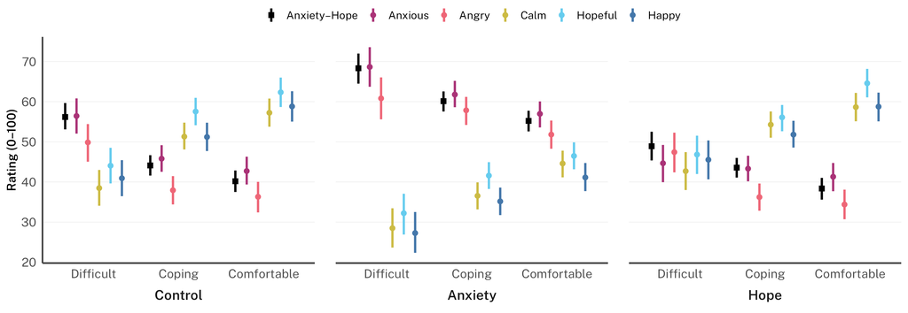

```r
ls_preds <- bind_rows(
  predictions(ah4, newdata = datagrid(exp_condition = unique, living_standard = unique)) |>
    as_tibble() |>
    mutate(outcome = "Anxiety–Hope"),
  predictions(er4, newdata = datagrid(exp_condition = unique, living_standard = unique)) |>
    as_tibble() |>
    mutate(outcome = as.character(group))
) |>
  mutate(
    across(c(estimate, conf.low, conf.high), \(x) x * 100),
    outcome = factor(outcome, levels = names(outcome_colors)),
    exp_condition = factor(exp_condition, levels = c("control", "anxiety", "hope"),
                           labels = c("Control", "Anxiety", "Hope"))
  )

ls_fig <- ls_preds |>
  ggplot(aes(x = living_standard, y = estimate, ymin = conf.low, ymax = conf.high,
             color = outcome, shape = outcome)) +
  geom_pointrange(position = position_dodge(width = 0.8), size = 0.5, linewidth = 1.1) +
  facet_grid(. ~ exp_condition, switch = "x") +
  scale_color_manual(values = outcome_colors, name = NULL) +
  scale_shape_manual(values = outcome_shapes, name = NULL) +
  guides(color = guide_legend(nrow = 1), shape = guide_legend(nrow = 1)) +
  labs(x = NULL, y = "Rating (0–100)") +
  theme_allround() +
  theme(
    # Strips below the x labels act as a nested condition axis
    strip.placement = "outside",
    strip.background = element_blank(),
    panel.spacing.x = unit(1.5, "lines"),
    panel.grid.major.y = element_line(color = "grey90", linewidth = 0.2)
  )

ls_fig
```

```r
ggsave(here(figure_dir, "moderation_living_standard.svg"), plot = ls_fig,
       width = 13, height = 4.5, web_fonts = svg_fonts)
```

```r
er4_mod_comps <- avg_comparisons(
  er4,
  newdata = datagrid(exp_condition = unique, living_standard = unique),
  variables = list(living_standard = "pairwise"),
  by = "group") |>
  me_tidy()

er4_mod_comps |> tt()
```

| Emotion | Contrast | Median | 95% HDI Lower | 95% HDI Upper |
| --- | --- | --- | --- | --- |
| Angry | Comfortable - Coping | -0.03143 | -0.06111 | -0.002014 |
| Angry | Comfortable - Difficult | -0.11885 | -0.15502 | -0.083963 |
| Angry | Coping - Difficult | -0.08734 | -0.12252 | -0.053187 |
| Anxious | Comfortable - Coping | -0.03299 | -0.05937 | -0.005329 |
| Anxious | Comfortable - Difficult | -0.09619 | -0.13041 | -0.064299 |
| Anxious | Coping - Difficult | -0.06326 | -0.09522 | -0.030061 |
| Calm | Comfortable - Coping | 0.06100 | 0.03410 | 0.089381 |
| Calm | Comfortable - Difficult | 0.16953 | 0.13469 | 0.201698 |
| Calm | Coping - Difficult | 0.10810 | 0.07599 | 0.141823 |
| Happy | Comfortable - Coping | 0.06834 | 0.03953 | 0.096829 |
| Happy | Comfortable - Difficult | 0.15007 | 0.11445 | 0.186008 |
| Happy | Coping - Difficult | 0.08128 | 0.04579 | 0.116147 |
| Hopeful | Comfortable - Coping | 0.06061 | 0.03370 | 0.090080 |
| Hopeful | Comfortable - Difficult | 0.16794 | 0.13420 | 0.203029 |
| Hopeful | Coping - Difficult | 0.10725 | 0.07327 | 0.141546 |

```r
er4_comp_diffs <- avg_comparisons(
  er4,
  newdata = datagrid(exp_condition = unique, living_standard = unique),
  variables = list(exp_condition = "pairwise"),
  by = c("group", "living_standard"),
  hypothesis = difference ~ pairwise | group + contrast) |>
  me_tidy()

er4_comp_diffs |> tt()
```

| Emotion | Contrast | Moderator Contrast | Median | 95% HDI Lower | 95% HDI Upper |
| --- | --- | --- | --- | --- | --- |
| Angry | anxiety - control | (Coping) - (Difficult) | 0.089402 | 0.002119 | 0.1725457 |
| Angry | anxiety - control | (Comfortable) - (Difficult) | 0.046000 | -0.038592 | 0.1324357 |
| Angry | anxiety - control | (Comfortable) - (Coping) | -0.043337 | -0.113018 | 0.0295063 |
| Angry | anxiety - hope | (Coping) - (Difficult) | 0.081864 | -0.004296 | 0.1684509 |
| Angry | anxiety - hope | (Comfortable) - (Difficult) | 0.040984 | -0.045431 | 0.1317898 |
| Angry | anxiety - hope | (Comfortable) - (Coping) | -0.041230 | -0.110332 | 0.0310606 |
| Angry | hope - control | (Coping) - (Difficult) | 0.006983 | -0.076459 | 0.0911506 |
| Angry | hope - control | (Comfortable) - (Difficult) | 0.004842 | -0.085542 | 0.0861346 |
| Angry | hope - control | (Comfortable) - (Coping) | -0.002522 | -0.073633 | 0.0712290 |
| Anxious | anxiety - control | (Coping) - (Difficult) | 0.037756 | -0.041513 | 0.1213094 |
| Anxious | anxiety - control | (Comfortable) - (Difficult) | 0.020141 | -0.063201 | 0.0987344 |
| Anxious | anxiety - control | (Comfortable) - (Coping) | -0.017405 | -0.082145 | 0.0497820 |
| Anxious | anxiety - hope | (Coping) - (Difficult) | -0.055210 | -0.137795 | 0.0270542 |
| Anxious | anxiety - hope | (Comfortable) - (Difficult) | -0.084048 | -0.167607 | 0.0008443 |
| Anxious | anxiety - hope | (Comfortable) - (Coping) | -0.028924 | -0.096430 | 0.0374340 |
| Anxious | hope - control | (Coping) - (Difficult) | 0.092468 | 0.010869 | 0.1693891 |
| Anxious | hope - control | (Comfortable) - (Difficult) | 0.104600 | 0.026789 | 0.1888362 |
| Anxious | hope - control | (Comfortable) - (Coping) | 0.010846 | -0.055094 | 0.0763882 |
| Calm | anxiety - control | (Coping) - (Difficult) | -0.047246 | -0.128137 | 0.0340645 |
| Calm | anxiety - control | (Comfortable) - (Difficult) | -0.026878 | -0.109112 | 0.0580021 |
| Calm | anxiety - control | (Comfortable) - (Coping) | 0.021060 | -0.049755 | 0.0857723 |
| Calm | anxiety - hope | (Coping) - (Difficult) | -0.035082 | -0.116685 | 0.0515463 |
| Calm | anxiety - hope | (Comfortable) - (Difficult) | 0.001321 | -0.086423 | 0.0839345 |
| Calm | anxiety - hope | (Comfortable) - (Coping) | 0.037102 | -0.031247 | 0.1050045 |
| Calm | hope - control | (Coping) - (Difficult) | -0.012460 | -0.089289 | 0.0666830 |
| Calm | hope - control | (Comfortable) - (Difficult) | -0.028245 | -0.109158 | 0.0547864 |
| Calm | hope - control | (Comfortable) - (Coping) | -0.016444 | -0.084982 | 0.0509055 |
| Happy | anxiety - control | (Coping) - (Difficult) | -0.024287 | -0.107349 | 0.0578632 |
| Happy | anxiety - control | (Comfortable) - (Difficult) | -0.040917 | -0.121433 | 0.0475045 |
| Happy | anxiety - control | (Comfortable) - (Coping) | -0.016710 | -0.090988 | 0.0539418 |
| Happy | anxiety - hope | (Coping) - (Difficult) | 0.016096 | -0.070125 | 0.1004685 |
| Happy | anxiety - hope | (Comfortable) - (Difficult) | 0.006042 | -0.079709 | 0.0915874 |
| Happy | anxiety - hope | (Comfortable) - (Coping) | -0.010163 | -0.081105 | 0.0590573 |
| Happy | hope - control | (Coping) - (Difficult) | -0.039471 | -0.126612 | 0.0374930 |
| Happy | hope - control | (Comfortable) - (Difficult) | -0.046621 | -0.130832 | 0.0313888 |
| Happy | hope - control | (Comfortable) - (Coping) | -0.007030 | -0.077420 | 0.0661429 |
| Hopeful | anxiety - control | (Coping) - (Difficult) | -0.040236 | -0.126556 | 0.0388072 |
| Hopeful | anxiety - control | (Comfortable) - (Difficult) | -0.039163 | -0.121940 | 0.0465794 |
| Hopeful | anxiety - control | (Comfortable) - (Coping) | 0.001372 | -0.064956 | 0.0728668 |
| Hopeful | anxiety - hope | (Coping) - (Difficult) | 0.001737 | -0.080392 | 0.0878183 |
| Hopeful | anxiety - hope | (Comfortable) - (Difficult) | -0.034851 | -0.117175 | 0.0533389 |
| Hopeful | anxiety - hope | (Comfortable) - (Coping) | -0.036030 | -0.105352 | 0.0311440 |
| Hopeful | hope - control | (Coping) - (Difficult) | -0.041783 | -0.122956 | 0.0380895 |
| Hopeful | hope - control | (Comfortable) - (Difficult) | -0.004995 | -0.089028 | 0.0766752 |
| Hopeful | hope - control | (Comfortable) - (Coping) | 0.037033 | -0.031797 | 0.1087842 |

#### Age (Continuous)

##### Models

```r
ah5 <- brm(
  data = df_mod,
  family = gaussian(),
  formula = anxiety_hope_dim ~ exp_condition * age_z,
  prior = priors,
  sample_prior = "yes",
  init = "random",
  chains = chains,
  iter = iter,
  warmup = warmup,
  seed = bayes_seed,
  control = list(
    adapt_delta = adapt_delta,
    max_treedepth = max_treedepth),
  file = here(model_dir, "ah5.rds")
  )
```

```r
ah5_brms <- tidy(ah5, robust = TRUE, conf.method = "HPDinterval", rhat = TRUE, ess = TRUE) |>
  filter(effect == "fixed") |>
  mutate(term = case_when(
    term == "(Intercept)"                  ~ "Intercept",
    term == "exp_conditionhope"            ~ "Hope (vs. Control)",
    term == "exp_conditionanxiety"         ~ "Anxiety (vs. Control)",
    term == "age_z"                        ~ "Age (z)",
    term == "exp_conditionhope:age_z"      ~ "Age x Hope",
    term == "exp_conditionanxiety:age_z"   ~ "Age x Anxiety",
    TRUE ~ term
  )) |>
  select(Term = term,
         Median = estimate,
         MAD = std.error,
         "95% HDI Lower" = conf.low,
         "95% HDI Upper" = conf.high,
         "R-hat" = rhat,
         ESS = ess)
```

```r
ah5_brms_table <- ah5_brms |>
  mutate(across(where(is.numeric), \(x) round(x, 3))) |>
  tt()

ah5_brms_table
```

| Term | Median | MAD | 95% HDI Lower | 95% HDI Upper | R-hat | ESS |
| --- | --- | --- | --- | --- | --- | --- |
| Intercept | 0.455 | 0.009 | 0.437 | 0.470 | 1.000 | 5938 |
| Hope (vs. Control) | -0.026 | 0.012 | -0.049 | -0.003 | 1.001 | 6436 |
| Anxiety (vs. Control) | 0.141 | 0.012 | 0.118 | 0.165 | 1.000 | 6092 |
| Age (z) | -0.015 | 0.008 | -0.031 | 0.002 | 1.000 | 4144 |
| Age x Hope | -0.021 | 0.012 | -0.044 | 0.002 | 1.000 | 4592 |
| Age x Anxiety | -0.027 | 0.012 | -0.052 | -0.004 | 1.000 | 4870 |

```r
ah5_brms_table |>
  save_tt(here(table_dir, "ah5_brms_table.docx"), overwrite = TRUE)
```

```r
er5 <- brm(
  data = df_mod,
  family = gaussian(),
  formula = bf(mvbind(Anxious, Angry, Hopeful, Happy, Calm) ~ exp_condition * age_z) +
    set_rescor(FALSE),
  prior = priors_er,
  sample_prior = "yes",
  init = "random",
  chains = chains,
  iter = iter,
  warmup = warmup,
  seed = bayes_seed,
  control = list(
    adapt_delta = adapt_delta,
    max_treedepth = max_treedepth
  )
)
```

```r
er5_brms_raw <- map(emotions, \(em) {
  tidy(er5, parameters = paste0("^b_", em), robust = TRUE,
       conf.method = "HPDinterval", rhat = TRUE, ess = TRUE) |>
    mutate(Outcome = em,
           term = str_remove(term, paste0("b_", em, "_")))
}) |>
  list_rbind()

er5_brms <- er5_brms_raw |>
  mutate(term = case_when(
    term == "(Intercept)"                  ~ "Intercept",
    term == "exp_conditionhope"            ~ "Hope (vs. Control)",
    term == "exp_conditionanxiety"         ~ "Anxiety (vs. Control)",
    term == "age_z"                        ~ "Age (z)",
    term == "exp_conditionhope:age_z"      ~ "Age x Hope",
    term == "exp_conditionanxiety:age_z"   ~ "Age x Anxiety",
    TRUE ~ term
  )) |>
  select(Outcome, Term = term,
         Median = estimate,
         MAD = std.error,
         "95% HDI Lower" = conf.low,
         "95% HDI Upper" = conf.high,
         "R-hat" = rhat,
         ESS = ess)
```

```r
er5_brms_table <- er5_brms |>
  mutate(across(where(is.numeric), \(x) round(x, 3))) |>
  select(-Outcome) |>
  tt() |>
  group_tt(i = list(
    "Anxious" = 1,
    "Angry"   = 7,
    "Hopeful" = 13,
    "Happy"   = 19,
    "Calm"    = 25
  ))

er5_brms_table
```

| Term | Median | MAD | 95% HDI Lower | 95% HDI Upper | R-hat | ESS |
| --- | --- | --- | --- | --- | --- | --- |
| Anxious | Anxious | Anxious | Anxious | Anxious | Anxious | Anxious |
| Intercept | 0.472 | 0.011 | 0.451 | 0.494 | 1.001 | 14010 |
| Hope (vs. Control) | -0.043 | 0.016 | -0.072 | -0.012 | 1.000 | 12831 |
| Anxiety (vs. Control) | 0.139 | 0.016 | 0.109 | 0.169 | 1.000 | 13972 |
| Age (z) | 0.012 | 0.011 | -0.009 | 0.032 | 1.000 | 7527 |
| Age x Hope | -0.018 | 0.015 | -0.046 | 0.014 | 1.000 | 8813 |
| Age x Anxiety | -0.027 | 0.015 | -0.056 | 0.004 | 1.000 | 9170 |
| Angry | Angry | Angry | Angry | Angry | Angry | Angry |
| Intercept | 0.401 | 0.012 | 0.377 | 0.423 | 1.001 | 14746 |
| Hope (vs. Control) | -0.022 | 0.017 | -0.056 | 0.009 | 1.000 | 13515 |
| Anxiety (vs. Control) | 0.158 | 0.017 | 0.125 | 0.190 | 1.000 | 12761 |
| Age (z) | 0.010 | 0.011 | -0.012 | 0.033 | 1.001 | 7514 |
| Age x Hope | -0.035 | 0.016 | -0.067 | -0.004 | 1.000 | 8755 |
| Age x Anxiety | -0.029 | 0.017 | -0.060 | 0.004 | 1.001 | 8287 |
| Hopeful | Hopeful | Hopeful | Hopeful | Hopeful | Hopeful | Hopeful |
| Intercept | 0.563 | 0.011 | 0.541 | 0.584 | 1.000 | 12714 |
| Hope (vs. Control) | 0.009 | 0.015 | -0.021 | 0.041 | 1.000 | 12173 |
| Anxiety (vs. Control) | -0.143 | 0.016 | -0.176 | -0.114 | 1.001 | 11599 |
| Age (z) | 0.042 | 0.011 | 0.020 | 0.064 | 1.001 | 8073 |
| Age x Hope | 0.024 | 0.016 | -0.007 | 0.054 | 1.001 | 9421 |
| Age x Anxiety | 0.026 | 0.016 | -0.007 | 0.056 | 1.001 | 9313 |
| Happy | Happy | Happy | Happy | Happy | Happy | Happy |
| Intercept | 0.517 | 0.011 | 0.495 | 0.539 | 1.001 | 12690 |
| Hope (vs. Control) | 0.011 | 0.016 | -0.020 | 0.042 | 1.001 | 12683 |
| Anxiety (vs. Control) | -0.156 | 0.016 | -0.189 | -0.125 | 1.000 | 12799 |
| Age (z) | 0.053 | 0.011 | 0.031 | 0.074 | 1.001 | 7030 |
| Age x Hope | 0.008 | 0.016 | -0.023 | 0.039 | 1.001 | 8962 |
| Age x Anxiety | -0.005 | 0.016 | -0.036 | 0.025 | 1.001 | 8537 |
| Calm | Calm | Calm | Calm | Calm | Calm | Calm |
| Intercept | 0.506 | 0.011 | 0.485 | 0.528 | 1.000 | 12984 |
| Hope (vs. Control) | 0.027 | 0.015 | -0.003 | 0.058 | 1.001 | 12765 |
| Anxiety (vs. Control) | -0.123 | 0.016 | -0.152 | -0.092 | 1.000 | 13612 |
| Age (z) | 0.054 | 0.011 | 0.033 | 0.075 | 1.000 | 8102 |
| Age x Hope | 0.013 | 0.015 | -0.019 | 0.041 | 1.000 | 9296 |
| Age x Anxiety | -0.007 | 0.016 | -0.037 | 0.024 | 1.001 | 8847 |

```r
er5_brms_table |>
  save_tt(here(table_dir, "er5_brms_table.docx"), overwrite = TRUE)
```

##### 1. Association across Conditions

```r
ah5_mod_slope <- avg_slopes(
  ah5,
  newdata = datagrid(exp_condition = unique),
  variables = "age_z") |>
  as_tibble() |>
  select(Median = estimate,
         "95% HDI Lower" = conf.low,
         "95% HDI Upper" = conf.high) |>
  mutate(across(where(is.numeric), \(x) x / age_sd, .names = "{.col} (per year)"))

ah5_mod_slope |> tt()
```

| Median | 95% HDI Lower | 95% HDI Upper | Median (per year) | 95% HDI Lower (per year) | 95% HDI Upper (per year) |
| --- | --- | --- | --- | --- | --- |
| -0.03094 | -0.04085 | -0.02179 | -0.01027 | -0.01356 | -0.007233 |

##### 2. Moderation of Treatment Effects

```r
ah5_slope_diffs <- avg_slopes(
  ah5,
  newdata = datagrid(exp_condition = unique),
  variables = "age_z",
  by = "exp_condition",
  hypothesis = ~ pairwise) |>
  as_tibble() |>
  select(Contrast = hypothesis,
         Median = estimate,
         "95% HDI Lower" = conf.low,
         "95% HDI Upper" = conf.high) |>
  mutate(across(where(is.numeric), \(x) x / age_sd, .names = "{.col} (per year)"))

ah5_slope_diffs |> tt()
```

| Contrast | Median | 95% HDI Lower | 95% HDI Upper | Median (per year) | 95% HDI Lower (per year) | 95% HDI Upper (per year) |
| --- | --- | --- | --- | --- | --- | --- |
| (hope) - (control) | -0.020884 | -0.04438 | 0.002223 | -0.006934 | -0.01474 | 0.0007382 |
| (anxiety) - (control) | -0.026658 | -0.05201 | -0.004283 | -0.008851 | -0.01727 | -0.0014219 |
| (anxiety) - (hope) | -0.005965 | -0.03055 | 0.017328 | -0.001981 | -0.01014 | 0.0057531 |

Supporting: condition contrasts at ages 16, 21, and 26

```r
ah5_comps <- comparisons(
  ah5,
  variables = list(exp_condition = "pairwise"),
  newdata = datagrid(age_z = to_age_z(c(16, 21, 26)))) |>
  as_tibble() |>
  mutate(age = round(age_z * age_sd + age_mean)) |>
  select(Contrast = contrast,
         Age = age,
         Median = estimate,
         "95% HDI Lower" = conf.low,
         "95% HDI Upper" = conf.high)

ah5_comps |> tt()
```

| Contrast | Age | Median | 95% HDI Lower | 95% HDI Upper |
| --- | --- | --- | --- | --- |
| hope - control | 16 | 0.01407 | -0.03700 | 0.063846 |
| hope - control | 21 | -0.02074 | -0.04484 | 0.002737 |
| hope - control | 26 | -0.05532 | -0.09494 | -0.015038 |
| anxiety - control | 16 | 0.19211 | 0.14332 | 0.242591 |
| anxiety - control | 21 | 0.14784 | 0.12344 | 0.171083 |
| anxiety - control | 26 | 0.10304 | 0.06155 | 0.144275 |
| anxiety - hope | 16 | 0.17856 | 0.12627 | 0.230271 |
| anxiety - hope | 21 | 0.16845 | 0.14446 | 0.193189 |
| anxiety - hope | 26 | 0.15831 | 0.11804 | 0.199664 |

##### 3. Anxiety–Hope and Emotion Ratings

Model predictions (median and 95% HDI) by condition across age; black lines show the anxiety–hope dimension.

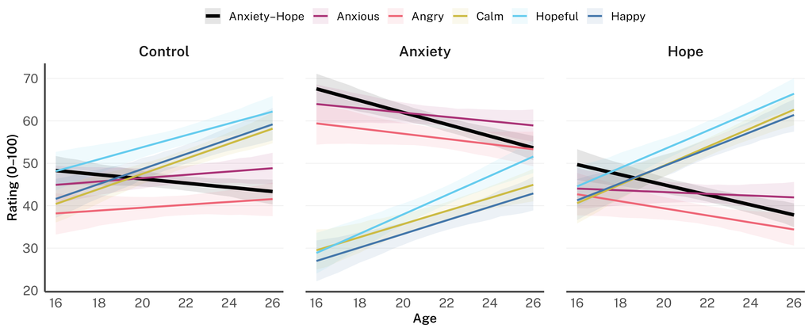

```r
age_preds <- bind_rows(
  predictions(ah5, newdata = datagrid(exp_condition = unique, age_z = to_age_z(seq(16, 26, by = 0.5)))) |>
    as_tibble() |>
    mutate(outcome = "Anxiety–Hope"),
  predictions(er5, newdata = datagrid(exp_condition = unique, age_z = to_age_z(seq(16, 26, by = 0.5)))) |>
    as_tibble() |>
    mutate(outcome = as.character(group))
) |>
  mutate(
    across(c(estimate, conf.low, conf.high), \(x) x * 100),
    age = age_z * age_sd + age_mean,
    outcome = factor(outcome, levels = names(outcome_colors)),
    exp_condition = factor(exp_condition, levels = c("control", "anxiety", "hope"),
                           labels = c("Control", "Anxiety", "Hope"))
  )

age_fig <- age_preds |>
  ggplot(aes(x = age, y = estimate, ymin = conf.low, ymax = conf.high,
             color = outcome, fill = outcome)) +
  geom_ribbon(alpha = 0.1, color = NA) +
  geom_line(aes(linewidth = outcome)) +
  facet_grid(. ~ exp_condition) +
  scale_color_manual(values = outcome_colors, name = NULL) +
  scale_fill_manual(values = outcome_colors, name = NULL) +
  scale_linewidth_manual(values = outcome_linewidths, name = NULL) +
  guides(color = guide_legend(nrow = 1), fill = guide_legend(nrow = 1),
         linewidth = guide_legend(nrow = 1)) +
  scale_x_continuous(breaks = seq(16, 26, 2)) +
  labs(x = "Age", y = "Rating (0–100)") +
  theme_allround() +
  theme(
    strip.background = element_blank(),
    panel.spacing.x = unit(1.5, "lines"),
    panel.grid.major.y = element_line(color = "grey90", linewidth = 0.2)
  )

age_fig
```

```r
ggsave(here(figure_dir, "moderation_age.svg"), plot = age_fig,
       width = 11, height = 4.5, web_fonts = svg_fonts)
```

```r
er5_mod_slope <- avg_slopes(
  er5,
  newdata = datagrid(exp_condition = unique),
  variables = "age_z",
  by = "group") |>
  as_tibble() |>
  select(Emotion = group,
         Median = estimate,
         "95% HDI Lower" = conf.low,
         "95% HDI Upper" = conf.high) |>
  mutate(across(where(is.numeric), \(x) x / age_sd, .names = "{.col} (per year)"))

er5_mod_slope |> tt()
```

| Emotion | Median | 95% HDI Lower | 95% HDI Upper | Median (per year) | 95% HDI Lower (per year) | 95% HDI Upper (per year) |
| --- | --- | --- | --- | --- | --- | --- |
| Angry | -0.011051 | -0.02434 | 0.001842 | -0.003669 | -0.008081 | 0.0006115 |
| Anxious | -0.003244 | -0.01527 | 0.009256 | -0.001077 | -0.005069 | 0.0030732 |
| Calm | 0.055609 | 0.04285 | 0.067829 | 0.018463 | 0.014228 | 0.0225203 |
| Happy | 0.053856 | 0.04066 | 0.066568 | 0.017881 | 0.013498 | 0.0221014 |
| Hopeful | 0.058836 | 0.04565 | 0.071359 | 0.019534 | 0.015157 | 0.0236922 |

```r
er5_slope_diffs <- avg_slopes(
  er5,
  newdata = datagrid(exp_condition = unique),
  variables = "age_z",
  by = c("group", "exp_condition"),
  hypothesis = difference ~ pairwise | group) |>
  as_tibble() |>
  select(Emotion = group,
         Contrast = hypothesis,
         Median = estimate,
         "95% HDI Lower" = conf.low,
         "95% HDI Upper" = conf.high) |>
  mutate(across(where(is.numeric), \(x) x / age_sd, .names = "{.col} (per year)"))

er5_slope_diffs |> tt()
```

| Emotion | Contrast | Median | 95% HDI Lower | 95% HDI Upper | Median (per year) | 95% HDI Lower (per year) | 95% HDI Upper (per year) |
| --- | --- | --- | --- | --- | --- | --- | --- |
| Angry | (hope) - (control) | -0.035039 | -0.067481 | -0.003901 | -0.0116334 | -0.022405 | -0.001295 |
| Angry | (anxiety) - (control) | -0.028540 | -0.059914 | 0.004066 | -0.0094757 | -0.019892 | 0.001350 |
| Angry | (anxiety) - (hope) | 0.006586 | -0.026143 | 0.037406 | 0.0021866 | -0.008680 | 0.012419 |
| Anxious | (hope) - (control) | -0.017755 | -0.046341 | 0.014031 | -0.0058950 | -0.015386 | 0.004658 |
| Anxious | (anxiety) - (control) | -0.027126 | -0.056022 | 0.004128 | -0.0090063 | -0.018600 | 0.001370 |
| Anxious | (anxiety) - (hope) | -0.009286 | -0.040139 | 0.021006 | -0.0030830 | -0.013327 | 0.006974 |
| Calm | (hope) - (control) | 0.012933 | -0.018523 | 0.041488 | 0.0042939 | -0.006150 | 0.013774 |
| Calm | (anxiety) - (control) | -0.006967 | -0.037428 | 0.024292 | -0.0023132 | -0.012426 | 0.008065 |
| Calm | (anxiety) - (hope) | -0.019683 | -0.052530 | 0.010645 | -0.0065352 | -0.017441 | 0.003534 |
| Happy | (hope) - (control) | 0.007657 | -0.022962 | 0.038589 | 0.0025423 | -0.007624 | 0.012812 |
| Happy | (anxiety) - (control) | -0.005121 | -0.036339 | 0.025043 | -0.0017002 | -0.012065 | 0.008315 |
| Happy | (anxiety) - (hope) | -0.012440 | -0.044929 | 0.018845 | -0.0041303 | -0.014917 | 0.006257 |
| Hopeful | (hope) - (control) | 0.023918 | -0.007025 | 0.053663 | 0.0079412 | -0.002332 | 0.017817 |
| Hopeful | (anxiety) - (control) | 0.026296 | -0.007091 | 0.055660 | 0.0087307 | -0.002354 | 0.018480 |
| Hopeful | (anxiety) - (hope) | 0.002511 | -0.029067 | 0.033225 | 0.0008336 | -0.009651 | 0.011031 |

#### Parental Ideology

##### Models

```r
ah6 <- brm(
  data = df_mod,
  family = gaussian(),
  formula = anxiety_hope_dim ~ exp_condition * parental_ideology_z,
  prior = priors,
  sample_prior = "yes",
  init = "random",
  chains = chains,
  iter = iter,
  warmup = warmup,
  seed = bayes_seed,
  control = list(
    adapt_delta = adapt_delta,
    max_treedepth = max_treedepth)
  )
```

```r
ah6_brms <- tidy(ah6, robust = TRUE, conf.method = "HPDinterval", rhat = TRUE, ess = TRUE) |>
  filter(effect == "fixed") |>
  mutate(term = case_when(
    term == "(Intercept)"                              ~ "Intercept",
    term == "exp_conditionhope"                        ~ "Hope (vs. Control)",
    term == "exp_conditionanxiety"                     ~ "Anxiety (vs. Control)",
    term == "parental_ideology_z"                      ~ "Parental Ideology (z)",
    term == "exp_conditionhope:parental_ideology_z"    ~ "Parental Ideology x Hope",
    term == "exp_conditionanxiety:parental_ideology_z" ~ "Parental Ideology x Anxiety",
    TRUE ~ term
  )) |>
  select(Term = term,
         Median = estimate,
         MAD = std.error,
         "95% HDI Lower" = conf.low,
         "95% HDI Upper" = conf.high,
         "R-hat" = rhat,
         ESS = ess)
```

```r
ah6_brms_table <- ah6_brms |>
  mutate(across(where(is.numeric), \(x) round(x, 3))) |>
  tt()

ah6_brms_table
```

| Term | Median | MAD | 95% HDI Lower | 95% HDI Upper | R-hat | ESS |
| --- | --- | --- | --- | --- | --- | --- |
| Intercept | 0.449 | 0.009 | 0.431 | 0.468 | 1.001 | 6236 |
| Hope (vs. Control) | -0.022 | 0.013 | -0.047 | 0.004 | 1.000 | 6330 |
| Anxiety (vs. Control) | 0.144 | 0.013 | 0.118 | 0.170 | 1.000 | 5723 |
| Parental Ideology (z) | -0.013 | 0.009 | -0.031 | 0.004 | 1.001 | 4286 |
| Parental Ideology x Hope | -0.002 | 0.013 | -0.028 | 0.023 | 1.001 | 5151 |
| Parental Ideology x Anxiety | -0.015 | 0.013 | -0.041 | 0.009 | 1.001 | 4597 |

```r
ah6_brms_table |>
  save_tt(here(table_dir, "ah6_brms_table.docx"), overwrite = TRUE)
```

```r
er6 <- brm(
  data = df_mod,
  family = gaussian(),
  formula = bf(mvbind(Anxious, Angry, Hopeful, Happy, Calm) ~ exp_condition * parental_ideology_z) +
    set_rescor(FALSE),
  prior = priors_er,
  sample_prior = "yes",
  init = "random",
  chains = chains,
  iter = iter,
  warmup = warmup,
  seed = bayes_seed,
  control = list(
    adapt_delta = adapt_delta,
    max_treedepth = max_treedepth
  )
)
```

```r
er6_brms_raw <- map(emotions, \(em) {
  tidy(er6, parameters = paste0("^b_", em), robust = TRUE,
       conf.method = "HPDinterval", rhat = TRUE, ess = TRUE) |>
    mutate(Outcome = em,
           term = str_remove(term, paste0("b_", em, "_")))
}) |>
  list_rbind()

er6_brms <- er6_brms_raw |>
  mutate(term = case_when(
    term == "(Intercept)"                              ~ "Intercept",
    term == "exp_conditionhope"                        ~ "Hope (vs. Control)",
    term == "exp_conditionanxiety"                     ~ "Anxiety (vs. Control)",
    term == "parental_ideology_z"                      ~ "Parental Ideology (z)",
    term == "exp_conditionhope:parental_ideology_z"    ~ "Parental Ideology x Hope",
    term == "exp_conditionanxiety:parental_ideology_z" ~ "Parental Ideology x Anxiety",
    TRUE ~ term
  )) |>
  select(Outcome, Term = term,
         Median = estimate,
         MAD = std.error,
         "95% HDI Lower" = conf.low,
         "95% HDI Upper" = conf.high,
         "R-hat" = rhat,
         ESS = ess)
```

```r
er6_brms_table <- er6_brms |>
  mutate(across(where(is.numeric), \(x) round(x, 3))) |>
  select(-Outcome) |>
  tt() |>
  group_tt(i = list(
    "Anxious" = 1,
    "Angry"   = 7,
    "Hopeful" = 13,
    "Happy"   = 19,
    "Calm"    = 25
  ))

er6_brms_table
```

| Term | Median | MAD | 95% HDI Lower | 95% HDI Upper | R-hat | ESS |
| --- | --- | --- | --- | --- | --- | --- |
| Anxious | Anxious | Anxious | Anxious | Anxious | Anxious | Anxious |
| Intercept | 0.480 | 0.012 | 0.455 | 0.502 | 1.001 | 14336 |
| Hope (vs. Control) | -0.042 | 0.017 | -0.075 | -0.009 | 1.000 | 13019 |
| Anxiety (vs. Control) | 0.135 | 0.017 | 0.104 | 0.169 | 1.000 | 14252 |
| Parental Ideology (z) | 0.020 | 0.012 | -0.003 | 0.043 | 1.001 | 8110 |
| Parental Ideology x Hope | 0.015 | 0.017 | -0.019 | 0.047 | 1.000 | 9082 |
| Parental Ideology x Anxiety | -0.023 | 0.017 | -0.055 | 0.009 | 1.000 | 9198 |
| Angry | Angry | Angry | Angry | Angry | Angry | Angry |
| Intercept | 0.404 | 0.013 | 0.381 | 0.428 | 1.001 | 14939 |
| Hope (vs. Control) | -0.022 | 0.018 | -0.056 | 0.013 | 1.000 | 13987 |
| Anxiety (vs. Control) | 0.158 | 0.018 | 0.124 | 0.193 | 1.000 | 13079 |
| Parental Ideology (z) | 0.002 | 0.013 | -0.024 | 0.027 | 1.001 | 7377 |
| Parental Ideology x Hope | -0.014 | 0.018 | -0.050 | 0.020 | 1.000 | 8355 |
| Parental Ideology x Anxiety | -0.001 | 0.017 | -0.034 | 0.033 | 1.000 | 8684 |
| Hopeful | Hopeful | Hopeful | Hopeful | Hopeful | Hopeful | Hopeful |
| Intercept | 0.581 | 0.012 | 0.557 | 0.605 | 1.000 | 14123 |
| Hope (vs. Control) | 0.002 | 0.017 | -0.030 | 0.038 | 1.000 | 12073 |
| Anxiety (vs. Control) | -0.153 | 0.017 | -0.185 | -0.120 | 1.000 | 12540 |
| Parental Ideology (z) | 0.047 | 0.012 | 0.024 | 0.070 | 1.000 | 7353 |
| Parental Ideology x Hope | 0.017 | 0.017 | -0.016 | 0.049 | 1.000 | 8682 |
| Parental Ideology x Anxiety | 0.007 | 0.016 | -0.025 | 0.040 | 1.000 | 8617 |
| Happy | Happy | Happy | Happy | Happy | Happy | Happy |
| Intercept | 0.532 | 0.012 | 0.509 | 0.556 | 1.000 | 14568 |
| Hope (vs. Control) | 0.007 | 0.017 | -0.029 | 0.038 | 1.000 | 12816 |
| Anxiety (vs. Control) | -0.169 | 0.017 | -0.204 | -0.137 | 1.000 | 13440 |
| Parental Ideology (z) | 0.053 | 0.012 | 0.029 | 0.077 | 1.000 | 7410 |
| Parental Ideology x Hope | 0.003 | 0.017 | -0.032 | 0.036 | 1.000 | 8440 |
| Parental Ideology x Anxiety | -0.018 | 0.017 | -0.052 | 0.015 | 1.000 | 8566 |
| Calm | Calm | Calm | Calm | Calm | Calm | Calm |
| Intercept | 0.519 | 0.012 | 0.495 | 0.543 | 1.000 | 16175 |
| Hope (vs. Control) | 0.019 | 0.017 | -0.015 | 0.051 | 1.000 | 12807 |
| Anxiety (vs. Control) | -0.131 | 0.017 | -0.165 | -0.100 | 1.000 | 14087 |
| Parental Ideology (z) | 0.052 | 0.012 | 0.029 | 0.075 | 1.000 | 7445 |
| Parental Ideology x Hope | 0.019 | 0.017 | -0.015 | 0.051 | 1.000 | 8468 |
| Parental Ideology x Anxiety | -0.014 | 0.016 | -0.046 | 0.020 | 1.000 | 8076 |

```r
er6_brms_table |>
  save_tt(here(table_dir, "er6_brms_table.docx"), overwrite = TRUE)
```

##### 1. Association across Conditions

```r
ah6_mod_slope <- avg_slopes(
  ah6,
  newdata = datagrid(exp_condition = unique),
  variables = "parental_ideology_z") |>
  as_tibble() |>
  select(Median = estimate,
         "95% HDI Lower" = conf.low,
         "95% HDI Upper" = conf.high) |>
  mutate(across(where(is.numeric), \(x) x / pi_sd, .names = "{.col} (per scale point)"))

ah6_mod_slope |> tt()
```

| Median | 95% HDI Lower | 95% HDI Upper | Median (per scale point) | 95% HDI Lower (per scale point) | 95% HDI Upper (per scale point) |
| --- | --- | --- | --- | --- | --- |
| -0.01892 | -0.02954 | -0.0086 | -0.007798 | -0.01217 | -0.003544 |

##### 2. Moderation of Treatment Effects

```r
ah6_slope_diffs <- avg_slopes(
  ah6,
  newdata = datagrid(exp_condition = unique),
  variables = "parental_ideology_z",
  by = "exp_condition",
  hypothesis = ~ pairwise) |>
  as_tibble() |>
  select(Contrast = hypothesis,
         Median = estimate,
         "95% HDI Lower" = conf.low,
         "95% HDI Upper" = conf.high) |>
  mutate(across(where(is.numeric), \(x) x / pi_sd, .names = "{.col} (per scale point)"))

ah6_slope_diffs |> tt()
```

| Contrast | Median | 95% HDI Lower | 95% HDI Upper | Median (per scale point) | 95% HDI Lower (per scale point) | 95% HDI Upper (per scale point) |
| --- | --- | --- | --- | --- | --- | --- |
| (hope) - (control) | -0.001517 | -0.02826 | 0.022991 | -0.0006252 | -0.01165 | 0.009475 |
| (anxiety) - (control) | -0.015144 | -0.04061 | 0.008993 | -0.0062408 | -0.01674 | 0.003706 |
| (anxiety) - (hope) | -0.013679 | -0.03802 | 0.013000 | -0.0056372 | -0.01567 | 0.005357 |

Supporting: condition contrasts at parental ideology 0 (left), 5, and 10 (right)

```r
ah6_comps <- comparisons(
  ah6,
  variables = list(exp_condition = "pairwise"),
  newdata = datagrid(parental_ideology_z = to_pi_z(c(0, 5, 10)))) |>
  as_tibble() |>
  mutate(parental_ideology = round(parental_ideology_z * pi_sd + pi_mean)) |>
  select(Contrast = contrast,
         `Parental Ideology` = parental_ideology,
         Median = estimate,
         "95% HDI Lower" = conf.low,
         "95% HDI Upper" = conf.high)

ah6_comps |> tt()
```

| Contrast | Parental Ideology | Median | 95% HDI Lower | 95% HDI Upper |
| --- | --- | --- | --- | --- |
| hope - control | 0 | -0.01880 | -0.08251 | 0.045164 |
| hope - control | 5 | -0.02129 | -0.04671 | 0.005833 |
| hope - control | 10 | -0.02430 | -0.07594 | 0.031774 |
| anxiety - control | 0 | 0.17909 | 0.11466 | 0.240130 |
| anxiety - control | 5 | 0.14752 | 0.12114 | 0.173864 |
| anxiety - control | 10 | 0.11601 | 0.06257 | 0.167811 |
| anxiety - hope | 0 | 0.19688 | 0.13462 | 0.262521 |
| anxiety - hope | 5 | 0.16876 | 0.14179 | 0.193989 |
| anxiety - hope | 10 | 0.13998 | 0.08756 | 0.194281 |

##### 3. Anxiety–Hope and Emotion Ratings

Model predictions (median and 95% HDI) by condition across parental ideology; black lines show the anxiety–hope dimension.

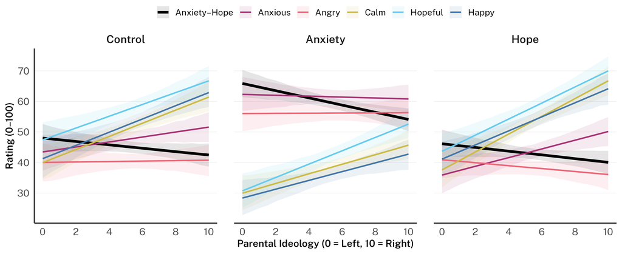

```r
pi_preds <- bind_rows(
  predictions(ah6, newdata = datagrid(exp_condition = unique, parental_ideology_z = to_pi_z(seq(0, 10, by = 0.5)))) |>
    as_tibble() |>
    mutate(outcome = "Anxiety–Hope"),
  predictions(er6, newdata = datagrid(exp_condition = unique, parental_ideology_z = to_pi_z(seq(0, 10, by = 0.5)))) |>
    as_tibble() |>
    mutate(outcome = as.character(group))
) |>
  mutate(
    across(c(estimate, conf.low, conf.high), \(x) x * 100),
    parental_ideology = parental_ideology_z * pi_sd + pi_mean,
    outcome = factor(outcome, levels = names(outcome_colors)),
    exp_condition = factor(exp_condition, levels = c("control", "anxiety", "hope"),
                           labels = c("Control", "Anxiety", "Hope"))
  )

pi_fig <- pi_preds |>
  ggplot(aes(x = parental_ideology, y = estimate, ymin = conf.low, ymax = conf.high,
             color = outcome, fill = outcome)) +
  geom_ribbon(alpha = 0.1, color = NA) +
  geom_line(aes(linewidth = outcome)) +
  facet_grid(. ~ exp_condition) +
  scale_color_manual(values = outcome_colors, name = NULL) +
  scale_fill_manual(values = outcome_colors, name = NULL) +
  scale_linewidth_manual(values = outcome_linewidths, name = NULL) +
  guides(color = guide_legend(nrow = 1), fill = guide_legend(nrow = 1),
         linewidth = guide_legend(nrow = 1)) +
  scale_x_continuous(breaks = seq(0, 10, 2)) +
  labs(x = "Parental Ideology (0 = Left, 10 = Right)", y = "Rating (0–100)") +
  theme_allround() +
  theme(
    strip.background = element_blank(),
    panel.spacing.x = unit(1.5, "lines"),
    panel.grid.major.y = element_line(color = "grey90", linewidth = 0.2)
  )

pi_fig
```

```r
ggsave(here(figure_dir, "moderation_parental_ideology.svg"), plot = pi_fig,
       width = 11, height = 4.5, web_fonts = svg_fonts)
```

```r
er6_mod_slope <- avg_slopes(
  er6,
  newdata = datagrid(exp_condition = unique),
  variables = "parental_ideology_z",
  by = "group") |>
  as_tibble() |>
  select(Emotion = group,
         Median = estimate,
         "95% HDI Lower" = conf.low,
         "95% HDI Upper" = conf.high) |>
  mutate(across(where(is.numeric), \(x) x / pi_sd, .names = "{.col} (per scale point)"))

er6_mod_slope |> tt()
```

| Emotion | Median | 95% HDI Lower | 95% HDI Upper | Median (per scale point) | 95% HDI Lower (per scale point) | 95% HDI Upper (per scale point) |
| --- | --- | --- | --- | --- | --- | --- |
| Angry | -0.00310 | -0.017298 | 0.01112 | -0.001278 | -0.007129 | 0.004583 |
| Anxious | 0.01687 | 0.003897 | 0.03069 | 0.006952 | 0.001606 | 0.012646 |
| Calm | 0.05351 | 0.040723 | 0.06688 | 0.022053 | 0.016782 | 0.027561 |
| Happy | 0.04770 | 0.034715 | 0.06183 | 0.019656 | 0.014306 | 0.025480 |
| Hopeful | 0.05461 | 0.041077 | 0.06760 | 0.022507 | 0.016928 | 0.027857 |

```r
er6_slope_diffs <- avg_slopes(
  er6,
  newdata = datagrid(exp_condition = unique),
  variables = "parental_ideology_z",
  by = c("group", "exp_condition"),
  hypothesis = difference ~ pairwise | group) |>
  as_tibble() |>
  select(Emotion = group,
         Contrast = hypothesis,
         Median = estimate,
         "95% HDI Lower" = conf.low,
         "95% HDI Upper" = conf.high) |>
  mutate(across(where(is.numeric), \(x) x / pi_sd, .names = "{.col} (per scale point)"))

er6_slope_diffs |> tt()
```

| Emotion | Contrast | Median | 95% HDI Lower | 95% HDI Upper | Median (per scale point) | 95% HDI Lower (per scale point) | 95% HDI Upper (per scale point) |
| --- | --- | --- | --- | --- | --- | --- | --- |
| Angry | (hope) - (control) | -0.013725 | -0.04952 | 0.0200048 | -0.0056562 | -0.020406 | 0.0082439 |
| Angry | (anxiety) - (control) | -0.001160 | -0.03433 | 0.0331775 | -0.0004782 | -0.014149 | 0.0136724 |
| Angry | (anxiety) - (hope) | 0.012456 | -0.02173 | 0.0448682 | 0.0051332 | -0.008953 | 0.0184901 |
| Anxious | (hope) - (control) | 0.014797 | -0.01874 | 0.0467249 | 0.0060978 | -0.007725 | 0.0192553 |
| Anxious | (anxiety) - (control) | -0.023303 | -0.05526 | 0.0088266 | -0.0096033 | -0.022771 | 0.0036374 |
| Anxious | (anxiety) - (hope) | -0.038068 | -0.06926 | -0.0064761 | -0.0156880 | -0.028540 | -0.0026688 |
| Calm | (hope) - (control) | 0.018582 | -0.01524 | 0.0507224 | 0.0076577 | -0.006281 | 0.0209026 |
| Calm | (anxiety) - (control) | -0.013960 | -0.04581 | 0.0197022 | -0.0057529 | -0.018880 | 0.0081192 |
| Calm | (anxiety) - (hope) | -0.032526 | -0.06579 | -0.0009166 | -0.0134039 | -0.027111 | -0.0003777 |
| Happy | (hope) - (control) | 0.003285 | -0.03186 | 0.0357611 | 0.0013539 | -0.013131 | 0.0147371 |
| Happy | (anxiety) - (control) | -0.017605 | -0.05206 | 0.0145419 | -0.0072549 | -0.021456 | 0.0059927 |
| Happy | (anxiety) - (hope) | -0.020910 | -0.05450 | 0.0122494 | -0.0086169 | -0.022460 | 0.0050479 |
| Hopeful | (hope) - (control) | 0.017241 | -0.01557 | 0.0494826 | 0.0071048 | -0.006418 | 0.0203917 |
| Hopeful | (anxiety) - (control) | 0.006552 | -0.02483 | 0.0401216 | 0.0026999 | -0.010234 | 0.0165340 |
| Hopeful | (anxiety) - (hope) | -0.010747 | -0.04368 | 0.0215362 | -0.0044288 | -0.018000 | 0.0088750 |

#### Overview Figure

Treatment effects on the anxiety–hope dimension overall (ATE) and by age group, gender, and living standard.

```r
# ah1: Overall ATE
ah1.draws <- expand.grid(
  exp_condition = c("control", "anxiety", "hope")
) |>
  add_epred_draws(ah1, re_formula = NA) |>
  ungroup()

ah1.contrasts <- ah1.draws |>
  select(exp_condition, .draw, .epred) |>
  pivot_wider(names_from = exp_condition, values_from = .epred) |>
  mutate(
    `Anxiety - Control` = anxiety - control,
    `Hope - Control` = hope - control,
    `Anxiety - Hope` = anxiety - hope
  ) |>
  pivot_longer(
    cols = c(`Anxiety - Control`, `Hope - Control`, `Anxiety - Hope`),
    names_to = "contrast",
    values_to = "estimate"
  ) |>
  mutate(
    model = "ATE",
    subgroup = "ATE"
  )

# ah2: cATE by age group
ah2.draws <- expand.grid(
  exp_condition = c("control", "anxiety", "hope"),
  age_group = unique(df_mod$age_group)
) |>
  add_epred_draws(ah2, re_formula = NA) |>
  ungroup()

ah2.contrasts <- ah2.draws |>
  select(exp_condition, age_group, .draw, .epred) |>
  pivot_wider(names_from = exp_condition, values_from = .epred) |>
  mutate(
    `Anxiety - Control` = anxiety - control,
    `Hope - Control` = hope - control,
    `Anxiety - Hope` = anxiety - hope
  ) |>
  pivot_longer(
    cols = c(`Anxiety - Control`, `Hope - Control`, `Anxiety - Hope`),
    names_to = "contrast",
    values_to = "estimate"
  ) |>
  mutate(
    model = "Age",
    subgroup = as.character(age_group)
  ) |>
  select(-age_group)

# ah3: cATE by gender
ah3.draws <- expand.grid(
  exp_condition = c("control", "anxiety", "hope"),
  gender = unique(df_mod$gender)
) |>
  add_epred_draws(ah3, re_formula = NA) |>
  ungroup() |>
  filter(gender != "other")

ah3.contrasts <- ah3.draws |>
  select(exp_condition, gender, .draw, .epred) |>
  pivot_wider(names_from = exp_condition, values_from = .epred) |>
  mutate(
    `Anxiety - Control` = anxiety - control,
    `Hope - Control` = hope - control,
    `Anxiety - Hope` = anxiety - hope
  ) |>
  pivot_longer(
    cols = c(`Anxiety - Control`, `Hope - Control`, `Anxiety - Hope`),
    names_to = "contrast",
    values_to = "estimate"
  ) |>
  mutate(
    model = "Gender",
    subgroup = as.character(gender)
  ) |>
  select(-gender)

# ah4: cATE by living standard
ah4.draws <- expand.grid(
  exp_condition = c("control", "anxiety", "hope"),
  living_standard = levels(df_mod$living_standard)
) |>
  add_epred_draws(ah4, re_formula = NA) |>
  ungroup()

ah4.contrasts <- ah4.draws |>
  select(exp_condition, living_standard, .draw, .epred) |>
  pivot_wider(names_from = exp_condition, values_from = .epred) |>
  mutate(
    `Anxiety - Control` = anxiety - control,
    `Hope - Control` = hope - control,
    `Anxiety - Hope` = anxiety - hope
  ) |>
  pivot_longer(
    cols = c(`Anxiety - Control`, `Hope - Control`, `Anxiety - Hope`),
    names_to = "contrast",
    values_to = "estimate"
  ) |>
  mutate(
    model = "Living Standard",
    subgroup = as.character(living_standard)
  ) |>
  select(-living_standard)

ah_plot_data <- bind_rows(ah1.contrasts, ah2.contrasts, ah3.contrasts, ah4.contrasts) |>
  mutate(
    estimate = estimate * 100,
    contrast = factor(contrast, levels = c("Anxiety - Hope", "Anxiety - Control", "Hope - Control")),
    model = factor(model, levels = c("ATE", "Age", "Gender", "Living Standard")),
    subgroup = case_when(
      subgroup == "male" ~ "Men",
      subgroup == "female" ~ "Women",
      subgroup == "16-21 years" ~ "16-21",
      subgroup == "22-26 years" ~ "22-26",
      TRUE ~ subgroup
    ),
    subgroup = factor(subgroup, levels = c("ATE", "22-26", "16-21", "Women", "Men",
                                           "Comfortable", "Coping", "Difficult"))
  )

# Compute whether HDI excludes zero for each group
ah_hdi_check <- ah_plot_data |>
  group_by(model, contrast, subgroup) |>
  median_hdi(estimate, .width = 0.95) |>
  mutate(excludes_zero = if_else(sign(.lower) == sign(.upper), "Excludes zero", "Includes zero")) |>
  select(model, contrast, subgroup, excludes_zero)
```

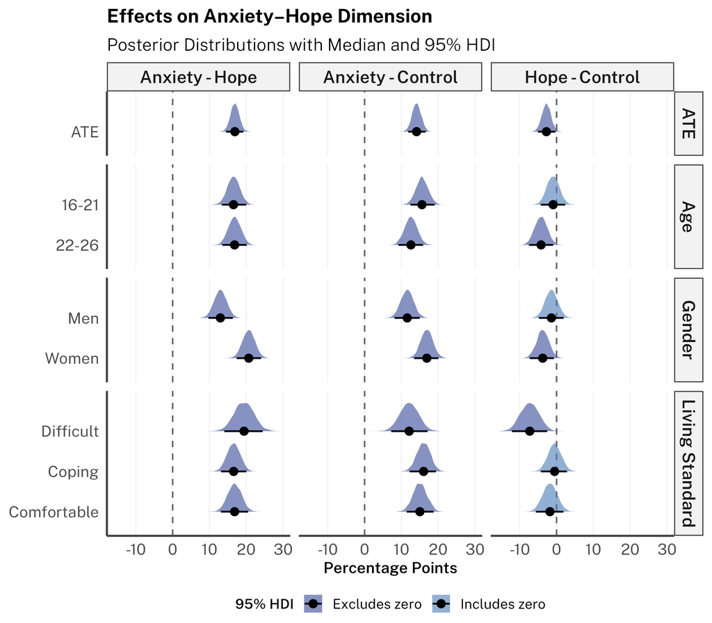

```r
ah_plot_data |>
  left_join(ah_hdi_check, by = c("model", "contrast", "subgroup")) |>
  ggplot(aes(x = estimate, y = subgroup, fill = excludes_zero)) +
  geom_vline(xintercept = 0, linetype = "dashed", color = "gray40", linewidth = 0.6) +
  stat_slabinterval(
    .width = c(.95),
    point_interval = "median_hdi",
    scale = 0.7,
    slab_alpha = 0.6,
    interval_alpha = 1,
    point_alpha = 1,
    normalize = "groups",
    point_size = 2.5,
    interval_size = 1.5) +
  facet_grid(model ~ contrast, scales = "free_y", space = "free_y") +
  scale_fill_manual(
    values = c("Excludes zero" = "#364B9A", "Includes zero" = "#4A7BB7"),
    name = "95% HDI"
  ) +
  scale_x_continuous(breaks = seq(-10, 30, by = 10)) +
  labs(
    x = "Percentage Points",
    y = NULL,
    title = "Effects on Anxiety–Hope Dimension",
    subtitle = "Posterior Distributions with Median and 95% HDI"
  ) +
  theme_allround() +
  theme(
    legend.position = "bottom",
    panel.grid.major.x = element_line(color = "grey90", linewidth = 0.2)
  )
```

```r
ggsave(here(figure_dir, "anxiety_hope_ate_cate_posterior.svg"), height = 7, width = 8, web_fonts = svg_fonts)
```

#### Raw Emotion Ratings by Subgroup

Raw mean (SD) emotion ratings (0–100) by condition overall and within each age group, gender, and level of living standard. The colour scale is centred on the scale midpoint (50).

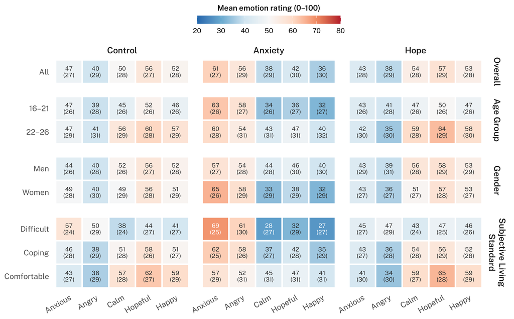

```r
# Raw mean (SD) emotion ratings by condition, overall and within each subgroup
means_heatmap_data <- bind_rows(
  df_mod |> mutate(moderator = "Overall", level = "All"),
  df_mod |> mutate(moderator = "Age Group", level = as.character(age_group)),
  df_mod |> filter(gender != "other") |> mutate(moderator = "Gender", level = as.character(gender)),
  df_mod |> mutate(moderator = "Subjective Living Standard", level = as.character(living_standard))
) |>
  filter(!is.na(level)) |>
  select(moderator, level, exp_condition,
         Anxious = exp_check_anxious, Angry = exp_check_angry, Calm = exp_check_calm,
         Hopeful = exp_check_hopeful, Happy = exp_check_happy) |>
  pivot_longer(Anxious:Happy, names_to = "emotion", values_to = "rating") |>
  summarise(mean = mean(rating, na.rm = TRUE), sd = sd(rating, na.rm = TRUE), n = sum(!is.na(rating)),
            .by = c(moderator, level, exp_condition, emotion)) |>
  mutate(
    emotion = factor(emotion, levels = c("Anxious", "Angry", "Calm", "Hopeful", "Happy")),
    exp_condition = factor(exp_condition, levels = c("control", "anxiety", "hope"),
                           labels = c("Control", "Anxiety", "Hope")),
    level = factor(level,
                   levels = c("All", "16-21 years", "22-26 years", "male", "female", "Difficult", "Coping", "Comfortable"),
                   labels = c("All", "16–21", "22–26", "Men", "Women", "Difficult", "Coping", "Comfortable")),
    moderator = factor(moderator, levels = c("Overall", "Age Group", "Gender", "Subjective Living Standard")),
    label = paste0(round(mean), "\n(", round(sd), ")")
  )

means_heatmap_fig <- means_heatmap_data |>
  ggplot(aes(x = emotion, y = fct_rev(level), fill = mean)) +
  geom_tile(color = "white", linewidth = 1) +
  geom_text(aes(label = label, color = abs(mean - 50) > 18), size = 3, lineheight = 0.9,
            family = "Public Sans Regular", show.legend = FALSE) +
  facet_grid(moderator ~ exp_condition, scales = "free_y", space = "free_y",
             labeller = labeller(moderator = label_wrap_gen(18))) +
  scale_fill_distiller(palette = "RdBu", direction = -1, limits = c(20, 80), oob = scales::squish,
                       breaks = seq(20, 80, 10), name = "Mean emotion rating (0–100)") +
  scale_color_manual(values = c(`TRUE` = "white", `FALSE` = "grey15")) +
  guides(fill = guide_colorbar(title.position = "top", title.hjust = 0.5,
                               barwidth = unit(14, "lines"), barheight = unit(0.8, "lines"))) +
  labs(x = NULL, y = NULL) +
  theme_allround(base_size = 12) +
  theme(
    legend.position = "top",
    legend.title = element_text(size = rel(0.9)),
    axis.line = element_blank(),
    axis.text.x = element_text(angle = 30, hjust = 1),
    strip.background = element_blank(),
    strip.text.y = element_text(angle = 270, lineheight = 1),
    panel.spacing = unit(0.8, "lines")
  )

means_heatmap_fig
```

```r
ggsave(here(figure_dir, "moderation_emotions_means_heatmap.svg"), plot = means_heatmap_fig,
       width = 10, height = 6.2, web_fonts = svg_fonts)
```